# Spatial and Economic Prioritization for Distributed Wind

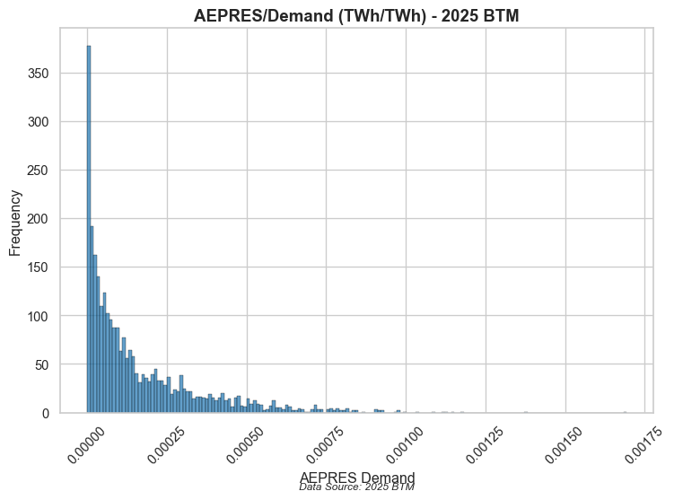

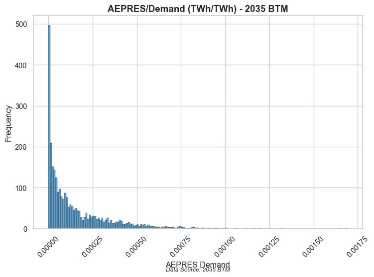

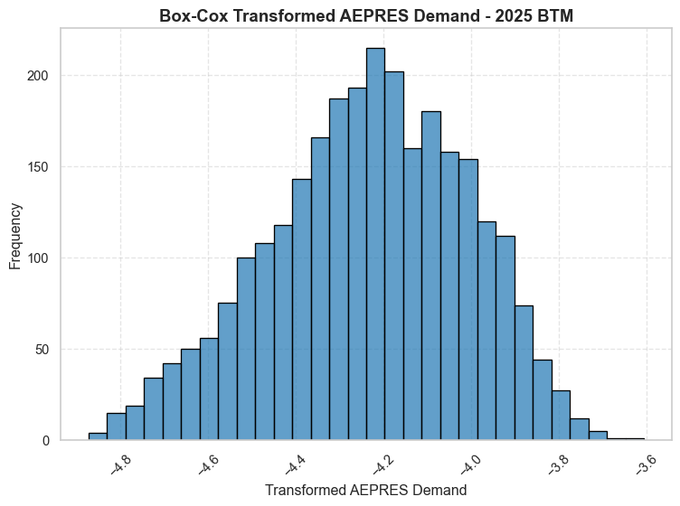

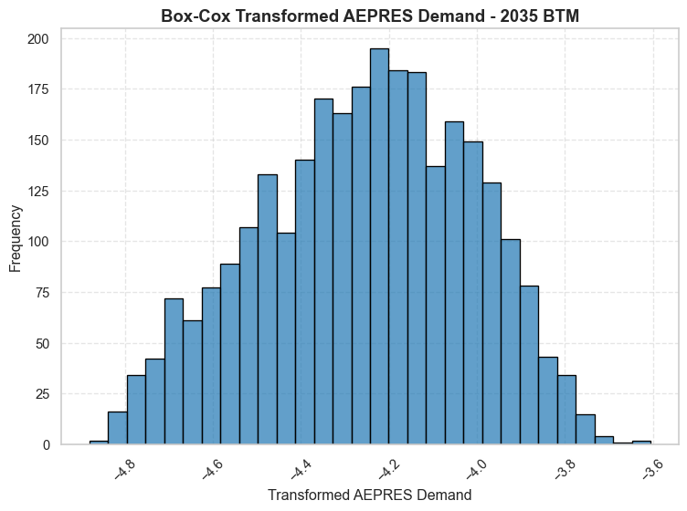

```
[2025 BTM] KS Test vs. Normal Distribution
  KS Statistic: nan
  p-value:      nan
  → Not significantly different from normal (p ≥ 0.05)
[2035 BTM] KS Test vs. Normal Distribution
  KS Statistic: nan
  p-value:      nan
  → Not significantly different from normal (p ≥ 0.05)
```

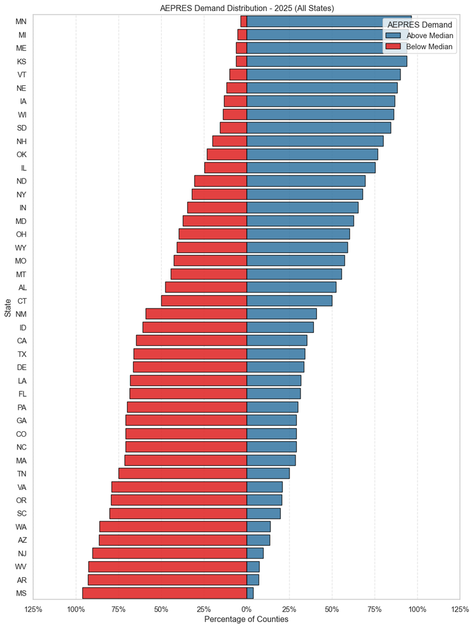

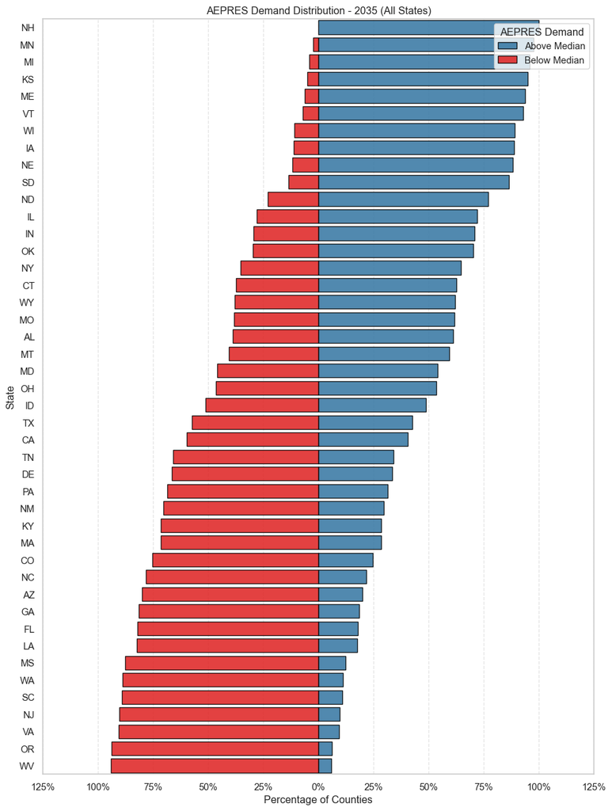

```python
plot_aepRES_histogram(df2025btm, "2025 BTM")
plot_aepRES_histogram(df2035btm, "2035 BTM")

# Box-Cox
plot_aepRES_boxcox_histogram(df2025btm['aepRES_demand_boxcox'], "2025 BTM")
plot_aepRES_boxcox_histogram(df2035btm['aepRES_demand_boxcox'], "2035 BTM")
# KS test against normal distribution
ks_test_transformed_aepRES(df2025btm['aepRES_demand_boxcox'], "2025 BTM")
ks_test_transformed_aepRES(df2035btm['aepRES_demand_boxcox'], "2035 BTM")

plot_aepRES_demand_distribution(df2025btm, title="AEPRES Demand Distribution - 2025")
plot_aepRES_demand_distribution(df2035btm, title="AEPRES Demand Distribution - 2035")
```

## 3.4 Correlations between metrics

```python
def kendall_tau_a(x, y):
    n = len(x)
    concordant = discordant = 0
    for i in range(n):
        for j in range(i + 1, n):
            concordant += (x[i] - x[j]) * (y[i] - y[j]) > 0
            discordant += (x[i] - x[j]) * (y[i] - y[j]) < 0
    return (concordant - discordant) / (0.5 * n * (n - 1))
```

### AEP-Demand (Residential) to Energy Burden.

State level

```python
import pandas as pd
import numpy as np
import geopandas as gpd
import matplotlib.pyplot as plt
import matplotlib.colors as mcolors
import requests, zipfile, os, tempfile
from scipy.stats import pearsonr, kendalltau

def compute_aepres_eb_correlations(df):
    df = df.copy()

    # Clean Box-Cox transformed data for Pearson
    clean_log = df[
        (~df['aepRES_demand_boxcox'].isna()) &
        (~df['EBres_boxcox'].isna()) &
        (~df['aepRES_demand_boxcox'].isin([np.inf, -np.inf])) &
        (df['aepRES_demand'] > 0)
    ][['aepRES_demand_boxcox', 'EBres_boxcox', 'state']]

    # Clean original (non-transformed) for Kendall
    clean_nc = df[
        (~df['aepRES_demand'].isna()) &
        (~df['EBres'].isna())
    ][['aepRES_demand', 'EBres', 'state']]

    states = df['state'].dropna().unique()

    pearson_corrs = []
    kendall_corrs = []

    for state in states:
        sub_log = clean_log[clean_log['state'] == state]
        sub_nc = clean_nc[clean_nc['state'] == state]

        # Pearson
        if len(sub_log) > 2 and sub_log['aepRES_demand_boxcox'].std() > 0:
            r, _ = pearsonr(sub_log['aepRES_demand_boxcox'], sub_log['EBres_boxcox'])
            pearson_corrs.append(r)
        else:
            pearson_corrs.append(np.nan)

        # Kendall
        if len(sub_nc) > 2 and sub_nc['aepRES_demand'].std() > 0:
            tau = kendall_tau_a(sub_nc['aepRES_demand'], sub_nc['EBres'])
            kendall_corrs.append(tau)
        else:
            kendall_corrs.append(np.nan)

    corr_df = pd.DataFrame({
        'state': states,
        'pearson': pearson_corrs,
        'kendall': kendall_corrs,
    })
    corr_df['difference'] = (corr_df['pearson'] - corr_df['kendall']).abs()

    return corr_df
```

```python
def compute_aepres_eb_correlations(df):
    df = df.copy()

    # Drop rows where aepRES_demand is missing or <= 0
    df = df[df['aepRES_demand'].notna() & (df['aepRES_demand'] > 0)]

    # Clean for Pearson (Box-Cox transformed data)
    clean_log = df[
        df['aepRES_demand_boxcox'].notna() &
        df['EBres_boxcox'].notna() &
        ~df['aepRES_demand_boxcox'].isin([np.inf, -np.inf])
    ][['aepRES_demand_boxcox', 'EBres_boxcox', 'state']]

    # Clean for Kendall (untransformed)
    clean_nc = df[
        df['EBres'].notna()
    ][['aepRES_demand', 'EBres', 'state']]

    states = df['state'].dropna().unique()

    pearson_corrs = []
    kendall_corrs = []

    for state in states:
        sub_log = clean_log[clean_log['state'] == state]
        sub_nc = clean_nc[clean_nc['state'] == state]

        if len(sub_log) > 2 and sub_log['aepRES_demand_boxcox'].std() > 0:
            r, _ = pearsonr(sub_log['aepRES_demand_boxcox'], sub_log['EBres_boxcox'])
            pearson_corrs.append(r)
        else:
            pearson_corrs.append(np.nan)

        if len(sub_nc) > 2 and sub_nc['aepRES_demand'].std() > 0:
            tau = kendall_tau_a(sub_nc['aepRES_demand'].to_numpy(), sub_nc['EBres'].to_numpy())
            kendall_corrs.append(tau)
        else:
            kendall_corrs.append(np.nan)

    corr_df = pd.DataFrame({
        'state': states,
        'pearson': pearson_corrs,
        'kendall': kendall_corrs
    })
    corr_df['difference'] = (corr_df['pearson'] - corr_df['kendall']).abs()
    return corr_df
```

```python
from matplotlib.colors import LinearSegmentedColormap

def plot_state_corr_map(corr_df, method='pearson', title_prefix='Correlation'):
    # Load US states shapefile (same method as your EB map)
    response = requests.get('https://github.com/sabrilg-nrel/mapsusdatasupport/raw/main/cb_2020_us_state_20m.zip')
    with tempfile.TemporaryDirectory() as tmpdirname:
        zip_path = os.path.join(tmpdirname, "cb_2020_us_state_20m.zip")
        with open(zip_path, "wb") as f:
            f.write(response.content)
        with zipfile.ZipFile(zip_path) as z:
            z.extractall(tmpdirname)
            shapefile_name = [f for f in z.namelist() if f.endswith('.shp')][0]
            shapefile_path = os.path.join(tmpdirname, shapefile_name)
            states_gdf = gpd.read_file(shapefile_path)


    states_gdf = states_gdf[~states_gdf['STUSPS'].isin(['AK', 'HI', 'PR'])]


    merged = states_gdf.merge(corr_df, left_on='STUSPS', right_on='state', how='left')

    r_style_cmap = LinearSegmentedColormap.from_list(
    "r_style_diverging", ["#00FF00", "#FFFFFF", "#800080"], N=256
)
    cmap = r_style_cmap
    norm = mcolors.TwoSlopeNorm(vmin=-1, vcenter=0, vmax=1)


    fig, ax = plt.subplots(figsize=(12, 8))
    merged.plot(column=method, cmap=cmap, norm=norm,
                linewidth=0.8, edgecolor='black', ax=ax, legend=True)

    ax.set_title(f"{title_prefix} ({method.capitalize()}) between AEPRES and EBres", fontsize=14)
    ax.axis('off')

    for idx, row in merged.iterrows():
        try:
            centroid = row['geometry'].centroid
            ax.text(centroid.x, centroid.y, row['STUSPS'], ha='center', va='center',
                    fontsize=8, fontweight='bold', color='black')
        except:
            continue

    plt.tight_layout()
    plt.show()
```

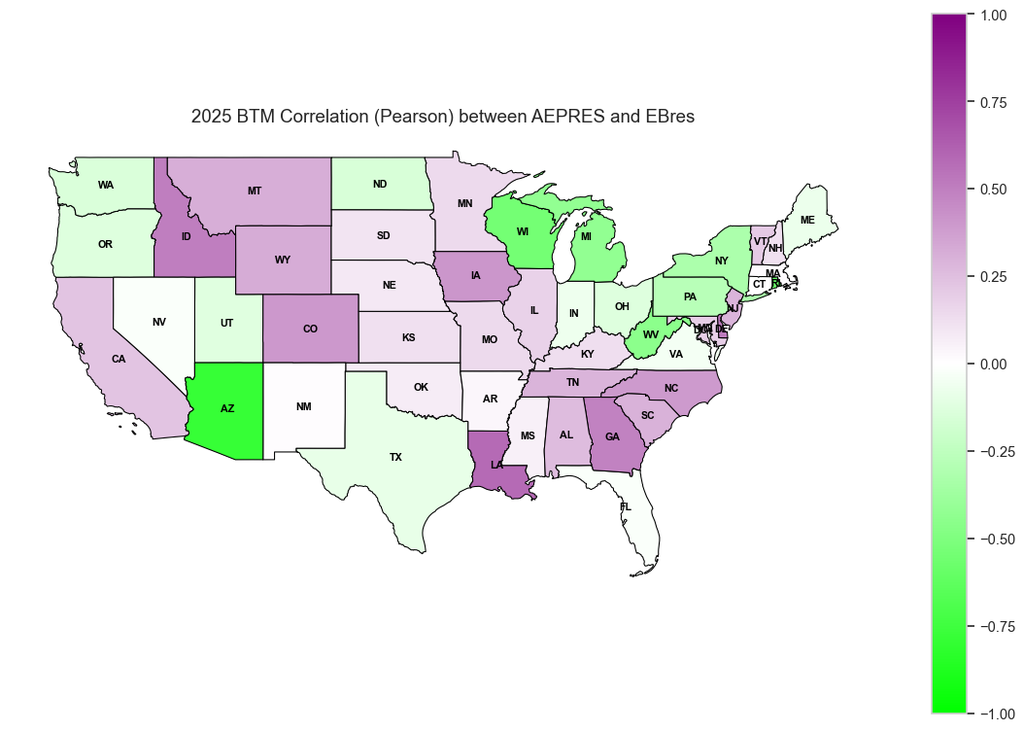

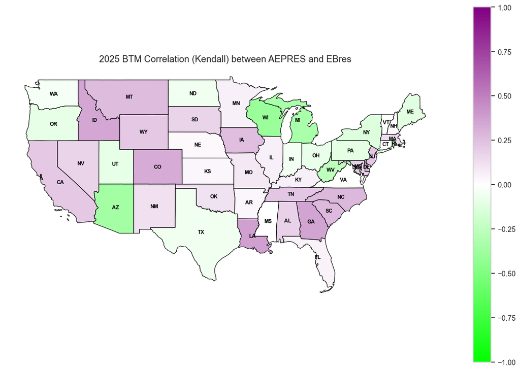

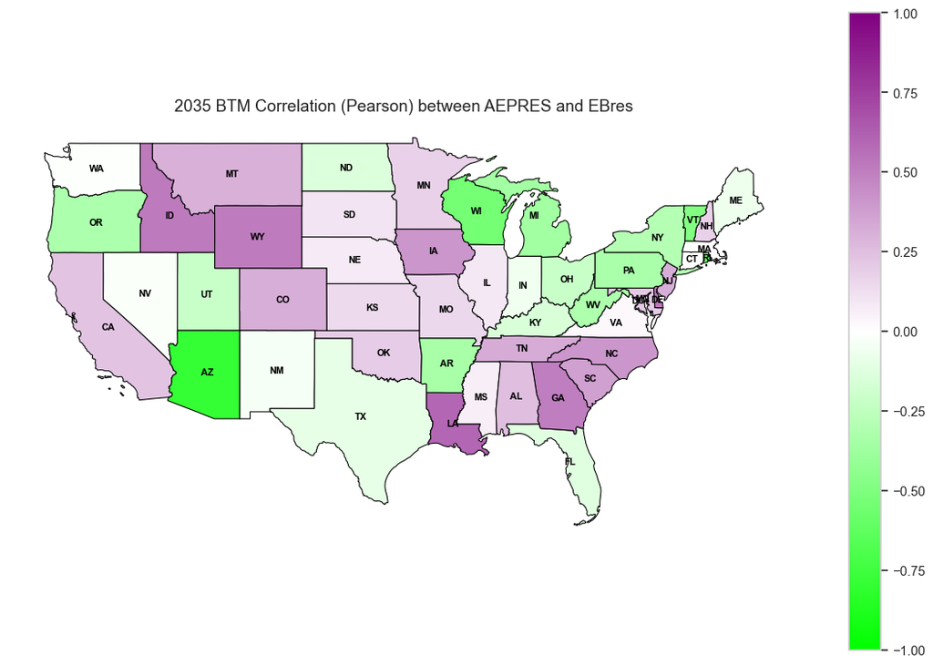

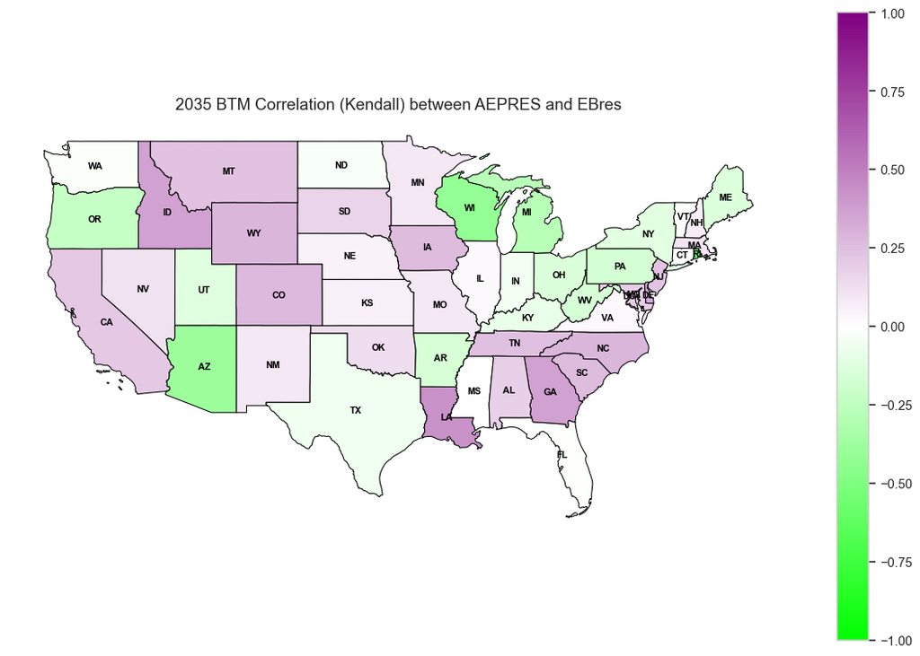

```python
corr2025 = compute_aepres_eb_correlations(df2025btm)
corr2035 = compute_aepres_eb_correlations(df2035btm)

plot_state_corr_map(corr2025, method='pearson', title_prefix='2025 BTM Correlation')
plot_state_corr_map(corr2025, method='kendall', title_prefix='2025 BTM Correlation')

plot_state_corr_map(corr2035, method='pearson', title_prefix='2035 BTM Correlation')
plot_state_corr_map(corr2035, method='kendall', title_prefix='2035 BTM Correlation')
```

Correlations are the same in python oand R. The only diference in ranking 3 and 2 at 2025 kendall due to a rounding.

### Rankings

```python
import pandas as pd

def rank_states_by_demand(df_demand, decoder_ring):
    # Join with decoder ring on 'fips' to get state info
    df_with_state = df_demand.merge(decoder_ring, on='fips', how='left')

    # Group by state and summarize
    state_summary = (
        df_with_state
        .groupby('state', as_index=False)
        .agg({
            'Residential_tWh': 'sum',
            'total_tWh': 'sum'
        })
    )

    # Filter out NA residential values and exclude Hawaii (HI)
    state_summary = state_summary[
        state_summary['Residential_tWh'].notna() & (state_summary['state'] != 'HI')
    ]

    # Rank and sort
    state_summary['rank_residential_dem'] = state_summary['Residential_tWh'].rank(ascending=False, method='min')
    state_summary['rank_total_dem'] = state_summary['total_tWh'].rank(ascending=False, method='min')

    # Select and sort columns
    ranked_states = (
        state_summary
        .sort_values(by='Residential_tWh', ascending=False)
        [['state', 'Residential_tWh', 'rank_residential_dem', 'total_tWh', 'rank_total_dem']]
    )

    return ranked_states
```

```python
# Apply the function to 2025 and 2035 data
rank_states25 = rank_states_by_demand(df_demand2025, decoder_ring)
rank_states35 = rank_states_by_demand(df_demand2035, decoder_ring)

# Merge rankings by state
rank_states = rank_states25[['state', 'rank_residential_dem', 'rank_total_dem']].merge(
    rank_states35[['state', 'rank_residential_dem', 'rank_total_dem']],
    on='state',
    suffixes=('_25', '_35')
)

# Sorting (similar to R arrange)
# rank_states.sort_values(by='rank_residential_dem_25')  # By 2025 residential rank
# rank_states.sort_values(by='rank_residential_dem_35')  # By 2035 residential rank
# rank_states.sort_values(by='rank_total_dem_25')        # By 2025 total demand rank
# rank_states.sort_values(by='rank_total_dem_35')        # By 2035 total demand rank
```

```python
def summarize_and_rank_aep(df, scenario_name):
    # Group by state and sum all relevant columns
    grouped = df.groupby('state').agg(
        cost_viable_aep_sum_twh=('cost_viable_aep_sum_twh', 'sum'),
        cost_viable_res_aep_sum_twh=('cost_viable_res_aep_sum_twh', 'sum'),
        total_tWh=('total_tWh', 'sum'),
        Residential_tWh=('Residential_tWh', 'sum')
    ).reset_index()

    # Calculate ratios per state (now using state-specific denominators)
    grouped['total_aep_demand'] = grouped['cost_viable_aep_sum_twh'] / grouped['total_tWh']
    grouped['total_res_aep_demand'] = grouped['cost_viable_res_aep_sum_twh'] / grouped['Residential_tWh']

    # Add total fields
    grouped['total_aep_res'] = grouped['cost_viable_res_aep_sum_twh']
    grouped['total_aep'] = grouped['cost_viable_aep_sum_twh']

    # Ranking
    grouped['rank_demand'] = grouped['total_aep_demand'].rank(ascending=False, method='min')
    grouped[f'rank_res_{scenario_name}'] = grouped['total_aep_res'].rank(ascending=False, method='min')
    grouped[f'rank_res_aep_demand_{scenario_name}'] = grouped['total_res_aep_demand'].rank(ascending=False, method='min')
    grouped[f'rank_total_aep_{scenario_name}'] = grouped['total_aep'].rank(ascending=False, method='min')

    grouped['scenario'] = scenario_name

    return grouped
```

```python
df_2025 = summarize_and_rank_aep(df2025btm, "2025")
df_2035 = summarize_and_rank_aep(df2035btm, "2035")
```

Correlations and rankings are the same in R and Python for both scenarios.

```python
corr2025_btm_AEPres_EB = corr2025.sort_values('kendall', ascending=False)
corr2025_btm_AEPres_EB['rank_kendall_25'] = range(1, len(corr2025) + 1)

corr2035_btm_AEPres_EB = corr2035.sort_values('kendall', ascending=False)
corr2035_btm_AEPres_EB['rank_kendall_35'] = range(1, len(corr2035) + 1)

# Merge on 'state'
df_ranking_comparison2535 = pd.merge(corr2025_btm_AEPres_EB[['state', 'rank_kendall_25']],
                                    pd.concat([df_2025, df_2035]),
                                    on='state', how='left')

df_ranking_comparison2535 = pd.merge(corr2035_btm_AEPres_EB[['state', 'rank_kendall_35']],
                                    df_ranking_comparison2535,
                                    on='state', how='left')
```

```python
# Pivot rank_demand column by scenario
pivot = df_ranking_comparison2535.pivot(index='state', columns='scenario', values='rank_demand')
pivot.columns = [f'rank_demand_{col}' for col in pivot.columns]

# Combine pivoted columns with original df
df_combined = df_ranking_comparison2535.merge(pivot, on='state', how='left')

# Define coalesce function (use first non-null)
def coalesce(series):
    return series.dropna().iloc[0] if not series.dropna().empty else np.nan

# Group by state and summarize with coalesce
def summarize_ranks(group):
    d = {
        'rank_res_aep_demand_2025': coalesce(group['rank_res_aep_demand_2025']),
        'rank_res_aep_demand_2035': coalesce(group['rank_res_aep_demand_2035']),
        'rank_demand_25': coalesce(group['rank_demand_2025']),
        'rank_demand_35': coalesce(group['rank_demand_2035']),
        'rank_kendall_25': coalesce(group['rank_kendall_25']),
        'rank_kendall_35': coalesce(group['rank_kendall_35']),
        'rank_res_2025': coalesce(group['rank_res_2025']),
        'rank_res_2035': coalesce(group['rank_res_2035']),
        'rank_total_aep_2025': coalesce(group['rank_total_aep_2025']),
        'rank_total_aep_2035': coalesce(group['rank_total_aep_2035']),
    }
    return pd.Series(d)

df_ranking_2025 = df_combined.groupby('state').apply(summarize_ranks).reset_index()
df_ranking_2025 = pd.merge(rank_states, df_ranking_2025, on='state', how='left')
```

```python
def sum_ignore_na(*args):
    return sum([x for x in args if pd.notnull(x)])

df_ranking_2025['rankW_tot'] = df_ranking_2025.apply(lambda r: sum_ignore_na(r['rank_total_aep_2025'], r['rank_total_aep_2035']), axis=1)
df_ranking_2025['rankW_AEP'] = df_ranking_2025.apply(lambda r: sum_ignore_na(r['rank_demand_25'], r['rank_demand_35']), axis=1)
df_ranking_2025['rank_corr'] = df_ranking_2025.apply(lambda r: sum_ignore_na(r['rank_kendall_25'], r['rank_kendall_35']), axis=1)
df_ranking_2025['rankW_AEP_demand_corr'] = df_ranking_2025.apply(lambda r: sum_ignore_na(
    r['rank_kendall_25'], r['rank_kendall_35'], r['rank_demand_25'], r['rank_demand_35']), axis=1)
df_ranking_2025['rankW_res_AEPdemand'] = df_ranking_2025.apply(lambda r: sum_ignore_na(
    r['rank_kendall_25'], r['rank_kendall_35'], r['rank_res_aep_demand_2025'], r['rank_res_aep_demand_2035']), axis=1)
df_ranking_2025['rankW_res'] = df_ranking_2025.apply(lambda r: sum_ignore_na(
    r['rank_kendall_25'], r['rank_kendall_35'], r['rank_res_2025'], r['rank_res_2035']), axis=1)
df_ranking_2025['rankW_res_AEPdemand_only'] = df_ranking_2025.apply(lambda r: sum_ignore_na(
    r['rank_res_aep_demand_2025'], r['rank_res_aep_demand_2035']), axis=1)
df_ranking_2025['rankRes_alone'] = df_ranking_2025.apply(lambda r: sum_ignore_na(
    r['rank_res_2025'], r['rank_res_2035']), axis=1)
df_ranking_2025['rankW_res_all'] = df_ranking_2025.apply(lambda r: sum_ignore_na(
    r['rank_kendall_25'], r['rank_kendall_35'], r['rank_res_2025'], r['rank_res_2035'],
    r['rank_res_aep_demand_2025'], r['rank_res_aep_demand_2035']), axis=1)
df_ranking_2025['rankW_res_all_AEP'] = df_ranking_2025.apply(lambda r: sum_ignore_na(
    r['rank_demand_25'], r['rank_demand_35']), axis=1)
```

```python
df_ranking_2025['rankW_res_demand'] = (
    0.5 * (df_ranking_2025['rank_kendall_25'] + df_ranking_2025['rank_kendall_35']) +
    0.25 * (df_ranking_2025['rank_res_aep_demand_2025'] + df_ranking_2025['rank_res_aep_demand_2035']) +
    0.25 * (df_ranking_2025['rank_residential_dem_25'] + df_ranking_2025['rank_residential_dem_25'])
)
```

Rankings work in R and Python

#### Group 1: High-Need, High-Potential States

```python
(df_ranking_2025.sort_values('rankW_res_demand').head(5))
```

|  | state | rank_residential_dem_25 | rank_total_dem_25 | rank_residential_dem_35 | rank_total_dem_35 | rank_res_aep_demand_2025 | rank_res_aep_demand_2035 | rank_demand_25 | rank_demand_35 | rank_kendall_25 | rank_kendall_35 | rank_res_2025 | rank_res_2035 | rank_total_aep_2025 | rank_total_aep_2035 | rankW_tot | rankW_AEP | rank_corr | rankW_AEP_demand_corr | rankW_res_AEPdemand | rankW_res | rankW_res_AEPdemand_only | rankRes_alone | rankW_res_all | rankW_res_all_AEP | rankW_res_demand |
| --- | --- | --- | --- | --- | --- | --- | --- | --- | --- | --- | --- | --- | --- | --- | --- | --- | --- | --- | --- | --- | --- | --- | --- | --- | --- | --- |
| 3 | NC | 4.0 | 9.0 | 4.0 | 9.0 | 27.0 | 33.0 | 20.0 | 25.0 | 6.0 | 5.0 | 15.0 | 17.0 | 9.0 | 11.0 | 20.0 | 45.0 | 11.0 | 56.0 | 71.0 | 43.0 | 60.0 | 32.0 | 103.0 | 45.0 | 22.50 |
| 6 | GA | 7.0 | 8.0 | 8.0 | 8.0 | 35.0 | 38.0 | 30.0 | 32.0 | 2.0 | 3.0 | 19.0 | 21.0 | 15.0 | 16.0 | 31.0 | 62.0 | 5.0 | 67.0 | 78.0 | 45.0 | 73.0 | 40.0 | 118.0 | 62.0 | 24.25 |
| 31 | IA | 32.0 | 28.0 | 32.0 | 27.0 | 4.0 | 4.0 | 12.0 | 11.0 | 9.0 | 8.0 | 10.0 | 8.0 | 17.0 | 17.0 | 34.0 | 23.0 | 17.0 | 40.0 | 25.0 | 35.0 | 8.0 | 18.0 | 43.0 | 23.0 | 26.50 |
| 2 | CA | 3.0 | 2.0 | 3.0 | 2.0 | 33.0 | 30.0 | 39.0 | 37.0 | 12.0 | 13.0 | 12.0 | 13.0 | 14.0 | 12.0 | 26.0 | 76.0 | 25.0 | 101.0 | 88.0 | 50.0 | 63.0 | 25.0 | 113.0 | 76.0 | 29.75 |
| 17 | LA | 18.0 | 17.0 | 17.0 | 16.0 | 38.0 | 41.0 | 42.0 | 44.0 | 1.0 | 1.0 | 26.0 | 34.0 | 29.0 | 33.0 | 62.0 | 86.0 | 2.0 | 88.0 | 81.0 | 62.0 | 79.0 | 60.0 | 141.0 | 86.0 | 29.75 |

#### Group 2: High AEP, Low-EB States

```python
(df_ranking_2025.sort_values('rankW_AEP').head(3))
```

|  | state | rank_residential_dem_25 | rank_total_dem_25 | rank_residential_dem_35 | rank_total_dem_35 | rank_res_aep_demand_2025 | rank_res_aep_demand_2035 | rank_demand_25 | rank_demand_35 | rank_kendall_25 | rank_kendall_35 | rank_res_2025 | rank_res_2035 | rank_total_aep_2025 | rank_total_aep_2035 | rankW_tot | rankW_AEP | rank_corr | rankW_AEP_demand_corr | rankW_res_AEPdemand | rankW_res | rankW_res_AEPdemand_only | rankRes_alone | rankW_res_all | rankW_res_all_AEP | rankW_res_demand |
| --- | --- | --- | --- | --- | --- | --- | --- | --- | --- | --- | --- | --- | --- | --- | --- | --- | --- | --- | --- | --- | --- | --- | --- | --- | --- | --- |
| 25 | WI | 26.0 | 22.0 | 26.0 | 22.0 | 6.0 | 6.0 | 1.0 | 1.0 | 46.0 | 46.0 | 5.0 | 6.0 | 1.0 | 1.0 | 2.0 | 2.0 | 92.0 | 94.0 | 104.0 | 103.0 | 12.0 | 11.0 | 115.0 | 2.0 | 62.00 |
| 23 | MN | 24.0 | 23.0 | 24.0 | 23.0 | 2.0 | 3.0 | 2.0 | 2.0 | 24.0 | 20.0 | 1.0 | 2.0 | 4.0 | 3.0 | 7.0 | 4.0 | 44.0 | 48.0 | 49.0 | 47.0 | 5.0 | 3.0 | 52.0 | 4.0 | 35.25 |
| 30 | KS | 31.0 | 32.0 | 31.0 | 31.0 | 5.0 | 5.0 | 3.0 | 3.0 | 27.0 | 24.0 | 13.0 | 12.0 | 11.0 | 9.0 | 20.0 | 6.0 | 51.0 | 57.0 | 61.0 | 76.0 | 10.0 | 25.0 | 86.0 | 6.0 | 43.50 |

## 3.5 Mixed effects modeling

First we standardize the columns for having more stability on the mixed model

```python
def check_high_sd_columns(df, year=None, threshold=5.0, exclude_cols=[0, 1, 2, 28]):

    include_cols = [col for idx, col in enumerate(df.columns) if idx not in exclude_cols]


    numeric_cols = df[include_cols].select_dtypes(include=[np.number])


    std_devs = numeric_cols.std(skipna=True)
    high_sd = std_devs[std_devs > threshold]

    result_df = pd.DataFrame({
        "Column": high_sd.index,
        "SD": high_sd.values
    })

    print(f"\nHigh SD columns for {year} (> {threshold}):")
    print(result_df)

    return high_sd.index.tolist()
def standardize_columns(df, columns):
    df = df.copy()
    for col in columns:
        df[f"{col}_standardized"] = (df[col] - df[col].mean()) / df[col].std()
    return df
```

```python
hsd2025 = check_high_sd_columns(df2025btm, year="2025", threshold=5.0)
hsd2035 = check_high_sd_columns(df2035btm, year="2035", threshold=5.0)
```

```
High SD columns for 2025 (> 5.0):
                                Column            SD
0              cost_viable_techpot_sum  6.501219e+05
1             cost_viable_capacity_sum  2.308705e+04
2           positive_breakeven_aep_sum  1.249046e+08
3       positive_breakeven_techpot_sum  8.126266e+05
4      positive_breakeven_capacity_sum  4.011720e+04
5                             Poverty%  5.334374e+00
6                       AgricultureInd  1.199506e+01
7                           UtilityInd  9.227832e+00
8                       ManufactureInd  1.188584e+01
9                   All industry total  3.481343e+07
10                            NonWhite  1.970681e+01
11             Median Household Income  1.629769e+04
12                         ResUnit2024  1.254872e+05
```

[output cut: 28 more lines]

```python
df2025btm = standardize_columns(df2025btm, hsd2025)
df2035btm = standardize_columns(df2035btm, hsd2035)
```

Energy buden as response variable

```python
from statsmodels.regression.mixed_linear_model import MixedLM
from statsmodels.tools import add_constant
from statsmodels.stats.outliers_influence import variance_inflation_factor
import statsmodels.api as sm
from statsmodels.regression.mixed_linear_model import MixedLM
from statsmodels.stats.outliers_influence import variance_inflation_factor
import pandas as pd

def fit_mixed_effects_model(df, outcome_var, group_var='state'):

    predictors = ['UnemploymentRate', 'Poverty%_standardized', 'AgricultureInd', 'NonWhite_standardized']
    df_model = df[[outcome_var, group_var] + predictors].dropna().copy()


    X = sm.add_constant(df_model[predictors])
    y = df_model[outcome_var]
    groups = df_model[group_var]


    model = MixedLM(endog=y, exog=X, groups=groups)
    model_fit = model.fit(reml=True)

    # VIF: Collinearity checker
    vif_data = pd.DataFrame()
    vif_data["variable"] = X.columns
    vif_data["VIF"] = [variance_inflation_factor(X.values, i) for i in range(X.shape[1])]

    return model_fit, vif_data
```

$R^2$ calculation

```python
def mixed_model_r_squared(model):


    fe_fitted = model.fittedvalues
    var_fixed = np.var(fe_fitted, ddof=1)


    try:
        var_random = float(model.cov_re.iloc[0, 0])
    except:
        var_random = 0


    var_resid = model.scale


    var_total = var_fixed + var_random + var_resid


    r2_marginal = var_fixed / var_total


    r2_conditional = (var_fixed + var_random) / var_total

    return {
        "R2_marginal": round(r2_marginal, 4),
        "R2_conditional": round(r2_conditional, 4),
        "Var_fixed": round(var_fixed, 4),
        "Var_random": round(var_random, 4),
        "Var_residual": round(var_resid, 4)
    }
```

```python
import matplotlib.pyplot as plt
import numpy as np
from scipy.stats import kstest, norm, probplot

def diagnostic_plots(model, model_name="Model"):

    fitted_vals = model.fittedvalues
    residuals = model.resid


    fig, axs = plt.subplots(1, 3, figsize=(18, 5))

    # 1. Residuals vs Fitted
    axs[0].scatter(fitted_vals, residuals, alpha=0.6, color="cornflowerblue")
    axs[0].axhline(0, color="red", linestyle="--")
    axs[0].set_title(f"Residuals vs Fitted: {model_name}")
    axs[0].set_xlabel("Fitted Values")
    axs[0].set_ylabel("Residuals")

    # 2. Q-Q Plot
    probplot(residuals, dist="norm", plot=axs[1])
    axs[1].set_title(f"QQ Plot: {model_name}")

    # 3. Histogram
    axs[2].hist(residuals, bins=30, color="lightblue", edgecolor="black")
    axs[2].set_title(f"Histogram of Residuals: {model_name}")
    axs[2].set_xlabel("Residuals")

    plt.tight_layout()
    plt.show()

    # 4. Kolmogorov–Smirnov test for normality
    ks_stat, p_val = kstest(residuals, 'norm', args=(np.mean(residuals), np.std(residuals)))
    print(f"\n--- {model_name} ---")
    print("Kolmogorov–Smirnov Test for Normality:")
    print(f"D = {ks_stat:.4f} | p-value = {p_val:.4f}\n")
```

### 2025 BTM

Energy Burden non transformed

```python
model_2025, vif_2025 = fit_mixed_effects_model(df2025btm, outcome_var='EBres')
print(model_2025.summary())
print(vif_2025)
r2_results = mixed_model_r_squared(model_2025)
print(r2_results)
```

```
             Mixed Linear Model Regression Results
================================================================
Model:                MixedLM   Dependent Variable:   EBres
No. Observations:     2851      Method:               REML
No. Groups:           48        Scale:                0.1240
Min. group size:      1         Log-Likelihood:       -1172.1500
Max. group size:      242       Converged:            Yes
Mean group size:      59.4
----------------------------------------------------------------
                      Coef.  Std.Err.   z    P>|z| [0.025 0.975]
----------------------------------------------------------------
const                  1.600    0.057 28.254 0.000  1.489  1.711
UnemploymentRate      -0.009    0.009 -1.053 0.292 -0.027  0.008
Poverty%_standardized  0.387    0.010 38.486 0.000  0.367  0.406
AgricultureInd         0.004    0.001  6.181 0.000  0.003  0.005
NonWhite_standardized -0.050    0.010 -4.960 0.000 -0.069 -0.030
Group Var              0.097    0.061
================================================================

                variable        VIF
0                  const  15.057435
1       UnemploymentRate   1.248028
2  Poverty%_standardized   1.489602
3         AgricultureInd   1.050925
4  NonWhite_standardized   1.322651
{'R2_marginal': np.float64(0.5161), 'R2_conditional': np.float64(0.7279), 'Var_fixed': 0.2353, 'Var_random': 0.0965, 'Var_residual': np.float64(0.124)}
```

Diagnosis for the model

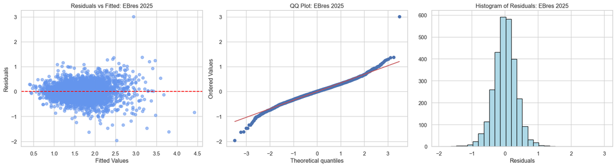

```
--- EBres 2025 ---
Kolmogorov–Smirnov Test for Normality:
D = 0.0301 | p-value = 0.0112
```

```python
diagnostic_plots(model_2025, model_name="EBres 2025")
```

Energy burden with Box-Cox transformation

```python
model_2025_bc, vif_2025_bc = fit_mixed_effects_model(df2025btm, outcome_var='EBres_boxcox')
print(model_2025_bc.summary())
print(vif_2025_bc)
```

```
             Mixed Linear Model Regression Results
================================================================
Model:              MixedLM   Dependent Variable:   EBres_boxcox
No. Observations:   2851      Method:               REML
No. Groups:         48        Scale:                0.0732
Min. group size:    1         Log-Likelihood:       -425.4909
Max. group size:    242       Converged:            Yes
Mean group size:    59.4
----------------------------------------------------------------
                      Coef.  Std.Err.   z    P>|z| [0.025 0.975]
----------------------------------------------------------------
const                  0.481    0.046 10.406 0.000  0.390  0.571
UnemploymentRate      -0.008    0.007 -1.237 0.216 -0.022  0.005
Poverty%_standardized  0.285    0.008 36.827 0.000  0.269  0.300
AgricultureInd         0.003    0.001  6.793 0.000  0.002  0.004
NonWhite_standardized -0.045    0.008 -5.844 0.000 -0.060 -0.030
Group Var              0.068    0.056
================================================================

                variable        VIF
0                  const  15.057435
1       UnemploymentRate   1.248028
2  Poverty%_standardized   1.489602
3         AgricultureInd   1.050925
4  NonWhite_standardized   1.322651
```

Diagnosis for the model

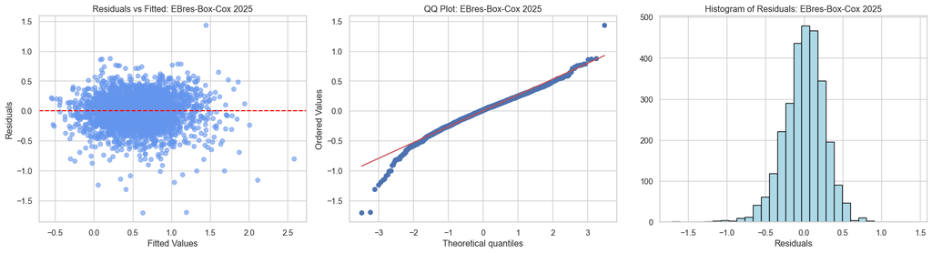

```
--- EBres-Box-Cox 2025 ---
Kolmogorov–Smirnov Test for Normality:
D = 0.0361 | p-value = 0.0011
```

```python
diagnostic_plots(model_2025_bc, model_name="EBres-Box-Cox 2025")
```

### 2035 BTM

Energy Burden non transformed

```python
model_2035, vif_2035 = fit_mixed_effects_model(df2035btm, outcome_var='EBres')
print(model_2035.summary())
print(vif_2035)
```

```
             Mixed Linear Model Regression Results
================================================================
Model:                MixedLM   Dependent Variable:   EBres
No. Observations:     2847      Method:               REML
No. Groups:           48        Scale:                0.1223
Min. group size:      1         Log-Likelihood:       -1147.9726
Max. group size:      242       Converged:            Yes
Mean group size:      59.3
----------------------------------------------------------------
                      Coef.  Std.Err.   z    P>|z| [0.025 0.975]
----------------------------------------------------------------
const                  1.582    0.054 29.414 0.000  1.476  1.687
UnemploymentRate      -0.005    0.009 -0.559 0.576 -0.022  0.012
Poverty%_standardized  0.380    0.010 38.149 0.000  0.361  0.400
AgricultureInd         0.004    0.001  6.028 0.000  0.003  0.005
NonWhite_standardized -0.051    0.010 -5.090 0.000 -0.070 -0.031
Group Var              0.083    0.053
================================================================

                variable        VIF
0                  const  14.863742
1       UnemploymentRate   1.256603
2  Poverty%_standardized   1.491528
3         AgricultureInd   1.051237
4  NonWhite_standardized   1.306037
```

Diagnosis for the model

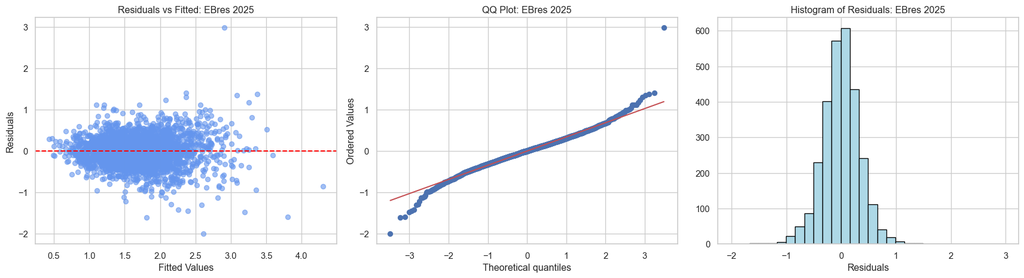

```
--- EBres 2025 ---
Kolmogorov–Smirnov Test for Normality:
D = 0.0296 | p-value = 0.0133
```

```python
diagnostic_plots(model_2035, model_name="EBres 2025")
```

Energy burden with Box-Cox transformation

```python
model_2035_bc, vif_2035_bc = fit_mixed_effects_model(df2035btm, outcome_var='EBres_boxcox')
print(model_2035_bc.summary())
print(vif_2035_bc)
```

```
             Mixed Linear Model Regression Results
================================================================
Model:              MixedLM   Dependent Variable:   EBres_boxcox
No. Observations:   2847      Method:               REML
No. Groups:         48        Scale:                0.0731
Min. group size:    1         Log-Likelihood:       -419.2226
Max. group size:    242       Converged:            Yes
Mean group size:    59.3
----------------------------------------------------------------
                      Coef.  Std.Err.   z    P>|z| [0.025 0.975]
----------------------------------------------------------------
const                  0.475    0.044 10.829 0.000  0.389  0.560
UnemploymentRate      -0.006    0.007 -0.934 0.350 -0.020  0.007
Poverty%_standardized  0.282    0.008 36.531 0.000  0.267  0.297
AgricultureInd         0.003    0.001  6.709 0.000  0.002  0.004
NonWhite_standardized -0.045    0.008 -5.850 0.000 -0.060 -0.030
Group Var              0.059    0.048
================================================================

                variable        VIF
0                  const  14.863742
1       UnemploymentRate   1.256603
2  Poverty%_standardized   1.491528
3         AgricultureInd   1.051237
4  NonWhite_standardized   1.306037
```

Diagnosis for the model

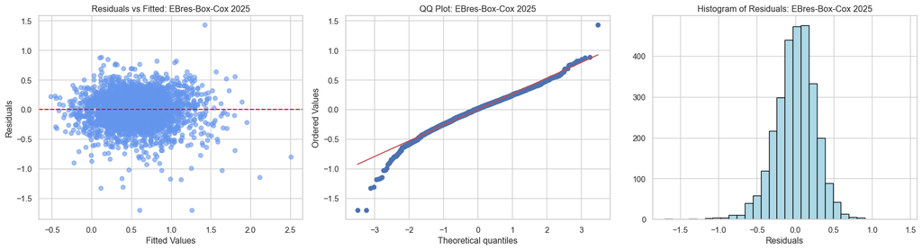

```
--- EBres-Box-Cox 2025 ---
Kolmogorov–Smirnov Test for Normality:
D = 0.0381 | p-value = 0.0005
```

```python
diagnostic_plots(model_2035_bc, model_name="EBres-Box-Cox 2025")
```

### Key Findings from Linear Mixed Models Relating Energy Burden to Socioeconomic Variables (2025 and 2035)

#### There is variability across states

The estimated variance due to the grouping variable (state) is larger than the standard error, which means there is variability across states.

#### **1. Poverty Rate Exhibits the Strongest Positive Association**

The standardized poverty percentage (`Poverty%_standardized`) consistently demonstrates a **strong, statistically significant positive effect** on energy burden:

**Interpretation:** Higher poverty rates are strongly associated with increased energy burdens. This indicates that households in areas with higher poverty levels are likely facing greater difficulty in affording energy.

#### **2. Agricultural Employment Share Shows a Positive Association** too.

The share of agricultural employment (`AgricultureInd`) is also consistently **positive and statistically significant**:

**Interpretation:** Counties with a higher share of agricultural employment tend to have weak-higher energy burdens, potentially due to rural infrastructure limitations and income instability in agricultural sectors.

#### **3. Nonwhite Population Share Shows a Negative Association**

The standardized nonwhite population share (`NonWhite_standardized`) has a **significant negative relationship** with energy burden:

**Interpretation:** After adjusting for poverty and rurality, counties with a higher percentage of nonwhite populations tend to show slightly lower energy burdens. This may reflect differences in urban versus rural contexts or variations in household energy consumption patterns.

#### **4. Unemployment Rate Shows a Weak Association**

The unemployment rate (`UnemploymentRate`) shows a **small and statistically insignificant effect** across all years:

**Interpretation:** The unemployment rate has a minimal impact on energy burden once other factors, such as poverty and structural economic conditions, are taken into account.

## 3.6 State - level regression models by group

First determine a good sample size

- `u = 4`: 4 predictors (independent variables),
  - `f2 = 0.35`: large effect size,
  - `sig.level = 0.01`: 1% significance level,
  - `power = 0.80`: 80% desired power.
- **`n = result$v + result$u + 1`**:
  - Calculates the required sample size (`n`):
    - `result$v`: residual degrees of freedom (related to `n - u - 1`),
    - `result$u`: number of predictors,
    - Adds 1 to account for the intercept.

```python
from statsmodels.stats.power import FTestPower
import numpy as np

# Parameters
f2 = 0.35
f = np.sqrt(f2)  # Cohen's f
alpha = 0.01
power = 0.80
u = 4  # Number of predictors (numerator df)

# Initialize power analysis
f_test = FTestPower()

# Solve for total sample size
n = f_test.solve_power(effect_size=f, df_num=u, alpha=alpha, power=power)

# Handle numpy array result
n_rounded = round(n.item())

print(f"Required sample size: 54")
```

```
Required sample size: 54
```

```python
def generate_state_summary(df, threshold=54):
    state_counts = df['state'].value_counts().sort_index()
    less_than_54 = state_counts[state_counts < threshold]
    more_than_54 = state_counts[state_counts >= threshold]

    print("### Data Count by State\n")

    print("#### States with less than 54 observations:")
    print("| State | Count |")
    print("|-------|-------|")
    for state, count in less_than_54.items():
        print(f"| {state} | {count} |")

    print("\n#### States with more than or equal to 54 observations:")
    print("| State | Count |")
    print("|-------|-------|")
    for state, count in more_than_54.items():
        print(f"| {state} | {count} |")


generate_state_summary(df2025btm)
```

```
### Data Count by State

#### States with less than 54 observations:
| State | Count |
|-------|-------|
| AZ | 15 |
| CT | 8 |
| DC | 1 |
| DE | 3 |
| ID | 41 |
| MA | 14 |
| MD | 24 |
| ME | 16 |
| ND | 39 |
| NH | 10 |
| NJ | 21 |
| NM | 27 |
| NV | 12 |
| OR | 34 |
| RI | 5 |
| SC | 46 |
| SD | 51 |
| UT | 19 |
| VT | 10 |
| WA | 29 |
| WY | 22 |

#### States with more than or equal to 54 observations:
| State | Count |
|-------|-------|
| AL | 67 |
| AR | 73 |
| CA | 57 |
| CO | 55 |
| FL | 67 |
| GA | 158 |
| IA | 97 |
| IL | 93 |
| IN | 92 |
| KS | 96 |
| KY | 76 |
| LA | 57 |
| MI | 73 |
| MN | 86 |
| MO | 115 |
| MS | 81 |
| MT | 54 |
| NC | 100 |
| NE | 93 |
| NY | 62 |
| OH | 88 |
| OK | 77 |
| PA | 67 |
| TN | 92 |
| TX | 242 |
| VA | 120 |
| WI | 72 |
| WV | 54 |
```

```python
import pandas as pd
import statsmodels.api as sm
import statsmodels.formula.api as smf

def lm_generation(df, state):

    df_state = df[df['state'] == state]


    model = smf.ols(
        formula='EBres ~ UnemploymentRate + Q("Poverty%_standardized") + AgricultureInd + NonWhite_standardized',
        data=df_state
    ).fit()

    return model

def lm_generation_interactions(df, state):

    df_state = df[df['state'] == state]


    model = smf.ols(
        formula='EBres ~ (UnemploymentRate + Q("Poverty%_standardized") + AgricultureInd + NonWhite_standardized)**2',
        data=df_state
    ).fit()

    return model
import matplotlib.pyplot as plt
import seaborn as sns
import numpy as np
from scipy import stats
import statsmodels.stats.api as sms

def diagnostic_plots(model, model_name="Model"):
    residuals = model.resid.dropna()
    fitted = model.fittedvalues.loc[residuals.index]

    plt.figure(figsize=(18, 5))

    # 1. Residuals vs Fitted
    plt.subplot(1, 3, 1)
    plt.scatter(fitted, residuals, color='cornflowerblue', edgecolor='k', alpha=0.7)
    plt.axhline(0, color='red', linestyle='--')
    plt.title(f"Residuals vs Fitted: {model_name}")
    plt.xlabel("Fitted Values")
    plt.ylabel("Residuals")

    # 2. QQ Plot
    plt.subplot(1, 3, 2)
    stats.probplot(residuals, dist="norm", plot=plt)
    plt.title(f"QQ Plot: {model_name}")

    # 3. Histogram of Residuals
    plt.subplot(1, 3, 3)
    sns.histplot(residuals, bins=30, kde=False, color='lightblue')
    plt.title(f"Histogram of Residuals: {model_name}")
    plt.xlabel("Residuals")

    plt.tight_layout()
    plt.show()

    # 4. Kolmogorov-Smirnov test for normality
    ks_stat, ks_pvalue = stats.kstest(
        residuals,
        'norm',
        args=(residuals.mean(), residuals.std())
    )

    # 5. Breusch-Pagan test for heteroskedasticity
    bp_test = sms.het_breuschpagan(residuals, model.model.exog)
    bp_stat, bp_pvalue = bp_test[0], bp_test[1]

    # Output test results
    print(f"\n--- {model_name} ---")
    print("Kolmogorov-Smirnov Test for Normality:")
    print(f"D = {ks_stat:.4f} | p-value = {ks_pvalue:.4f}")
    print("Breusch-Pagan Test for Homoskedasticity:")
    print(f"Chi-Sq = {bp_stat:.4f} | p-value = {bp_pvalue:.4f}\n")
```

```python
import matplotlib.pyplot as plt
import seaborn as sns
import numpy as np

def plot_energy_gdp_histogram(state_name, df):
    # Filter data by state
    state_data = df[df['state'] == state_name].copy()

    # Drop rows where energy_gdplog is NaN
    state_data = state_data[state_data['energy_gdplog'].notna()]

    if state_data.empty:
        print(f"Warning: No data available for state: {state_name}")
        return None

    median_state = state_data['energy_gdplog'].median()
    q90 = state_data['EBres'].quantile(0.9)
    q90_energy = state_data['energy_gdplog'].quantile(0.9)

    plt.figure(figsize=(10, 6))
    sns.histplot(state_data['energy_gdplog'], bins=15,
                 color='darkseagreen', edgecolor='darkseagreen', alpha=0.7)

    # Vertical lines
    plt.axvline(median_state, color='black', linestyle='dashed', linewidth=1, label='Median')
    plt.axvline(q90_energy, color='red', linestyle='dashed', linewidth=1, label='90th Percentile')

    # Titles and labels
    plt.title(f"Energy Burden GDP Distribution in {state_name}", fontsize=16, ha='center')
    plt.xlabel("Energy Burden GDP (log-transformed)", fontsize=14)
    plt.ylabel("Count of Counties", fontsize=14)

    # Annotate median and 90th percentile EBres
    plt.text(median_state - median_state / 5, 10,
             f"Median: {median_state:.2f}", color='black', fontsize=12)
    plt.text(median_state - median_state / 5, 9,
             f"90th Percentile EBres: {q90:.2f}", color='red', fontsize=12)

    plt.tight_layout()
    plt.legend()
    plt.show()
```

```python
def kendall_tau_a(x, y):
    x = np.asarray(x)
    y = np.asarray(y)
    n = len(x)
    concordant = discordant = 0
    for i in range(n):
        for j in range(i + 1, n):
            concordant += (x[i] - x[j]) * (y[i] - y[j]) > 0
            discordant += (x[i] - x[j]) * (y[i] - y[j]) < 0
    return (concordant - discordant) / (0.5 * n * (n - 1))
```

```python
import pandas as pd
import numpy as np
import seaborn as sns
import matplotlib.pyplot as plt
from scipy.stats import pearsonr, kendalltau

def corrAEP_EB_State(df, fombtm, scenario, state):
    # Filter by state
    df_state = df[df['state'] == state].copy()

    clean_df_log = df_state[
        (~np.isinf(df_state['aepRES_demand_boxcox'])) &
        (~df_state['aepRES_demand_boxcox'].isna()) &
        (~df_state['EBres_boxcox'].isna()) &
        (df_state['aepRES_demand'] > 0)
    ][['aepRES_demand', 'EBres_boxcox', 'aepRES_demand_boxcox']]

    clean_df_nc = df_state[
        (~df_state['aepRES_demand'].isna()) &
        (~df_state['EBres'].isna())
    ][['aepRES_demand', 'EBres']]

    # Check data sufficiency
    if len(clean_df_log) < 3 or len(clean_df_nc) < 3:
        print(f"Not enough data for {state} to calculate correlation.")
        return None

    # Calculate correlations with checks for zero std dev
    if clean_df_log['aepRES_demand_boxcox'].std() == 0:
        pearson_corr = np.nan
    else:
        pearson_corr, _ = pearsonr(clean_df_log['aepRES_demand_boxcox'], clean_df_log['EBres_boxcox'])

    if clean_df_nc['aepRES_demand'].std() == 0:
        kendall_corr = np.nan
    else:
        kendall_corr = kendall_tau_a(clean_df_nc['aepRES_demand'], clean_df_nc['EBres'])


    # Output results
    print(f"{state} {fombtm} {scenario}")
    print(f"Pearson Correlation (Box-Cox): {pearson_corr:.3f}")
    print(f"Kendall Correlation (Raw): {kendall_corr:.3f}")

    # Plot relationship (untransformed data)
    plt.figure(figsize=(8,6))
    sns.scatterplot(x='aepRES_demand', y='EBres', data=clean_df_nc, alpha=0.6, color="#4C90B1")
    sns.regplot(x='aepRES_demand', y='EBres', data=clean_df_nc,
                scatter=False, color='darkred', line_kws={'alpha':0.7}, ci=95)

    plt.xlabel("AEP Demand (TWh/house)")
    plt.ylabel("Energy Burden")
    plt.title(f"AEP vs Energy Burden - {state} {fombtm} {scenario}")
    plt.tight_layout()
    plt.show()

    return pd.DataFrame({
        'state': [state],
        'pearson': [pearson_corr],
        'kendall': [kendall_corr]
    })
```

```python
import matplotlib.pyplot as plt
import matplotlib.patches as mpatches
import geopandas as gpd
import numpy as np

def EB_county_map_state(df, summary_df, state_abbr):
    # Filter summary dataframe for the specific state, drop NA for mean_ebres and median_ebres
    summary_state = summary_df[
        (summary_df['state'] == state_abbr) &
        summary_df['mean_ebres'].notna() &
        summary_df['median_ebres'].notna()
    ]

    if summary_state.empty:
        print(f"No summary data available for state: {state_abbr}")
        return

    # Filter main df to state
    df_state = df[df['state'] == state_abbr].copy()

    # Join summary stats (mean, median) to main dataframe on state
    df_state = df_state.merge(
        summary_state[['state', 'mean_ebres', 'median_ebres']],
        on='state', how='left'
    )

    # Calculate difference from median for each county
    df_state['difference_from_median'] = df_state['EBres'] - df_state['median_ebres']

    # Prepare county shapes - you can reuse your existing method to load counties shapefile
    url = 'https://github.com/sabrilg-nrel/mapsusdatasupport/raw/main/cb_2020_us_county_20m.zip'
    import requests, zipfile, tempfile, os
    response = requests.get(url)
    with tempfile.TemporaryDirectory() as tmpdir:
        zip_path = os.path.join(tmpdir, "counties.zip")
        with open(zip_path, "wb") as f:
            f.write(response.content)
        with zipfile.ZipFile(zip_path) as z:
            z.extractall(tmpdir)
            shp_file = [f for f in z.namelist() if f.endswith('.shp')][0]
            shp_path = os.path.join(tmpdir, shp_file)
            counties = gpd.read_file(shp_path)

    # Exclude Alaska (02), Hawaii (15), Puerto Rico (72)
    counties = counties[~counties['STATEFP'].isin(['02', '15', '72'])]

    # Filter counties to the given state by matching STATEFP to FIPS codes of state (use your own mapping)
    # Here we will filter counties by state abbreviation, so need to map state_abbr to FIPS.
    # For simplicity, use 'STATEFP' codes for the state abbreviation from a lookup dict:

    state_fips_map = {
        # Add your states and FIPS mappings as needed
        'AL': '01', 'AK': '02', 'AZ': '04', 'AR': '05', 'CA': '06', 'CO': '08',
        'CT': '09', 'DE': '10', 'FL': '12', 'GA': '13', 'HI': '15', 'ID': '16',
        'IL': '17', 'IN': '18', 'IA': '19', 'KS': '20', 'KY': '21', 'LA': '22',
        'ME': '23', 'MD': '24', 'MA': '25', 'MI': '26', 'MN': '27', 'MS': '28',
        'MO': '29', 'MT': '30', 'NE': '31', 'NV': '32', 'NH': '33', 'NJ': '34',
        'NM': '35', 'NY': '36', 'NC': '37', 'ND': '38', 'OH': '39', 'OK': '40',
        'OR': '41', 'PA': '42', 'RI': '44', 'SC': '45', 'SD': '46', 'TN': '47',
        'TX': '48', 'UT': '49', 'VT': '50', 'VA': '51', 'WA': '53', 'WV': '54',
        'WI': '55', 'WY': '56'
    }

    state_fips = state_fips_map.get(state_abbr)
    if state_fips is None:
        print(f"State abbreviation {state_abbr} not recognized.")
        return

    counties_state = counties[counties['STATEFP'] == state_fips].copy()

    # Prepare FIPS code in both datasets to merge on
    df_state['fips'] = df_state['fips'].astype(str).str.zfill(5)
    counties_state['fips'] = counties_state['STATEFP'] + counties_state['COUNTYFP']

    # Merge spatial data with main df
    counties_state = counties_state.merge(df_state, on='fips', how='left')

    # Set color for above/below mean
    counties_state['county_color_mean'] = np.where(
        counties_state['EBres'] < counties_state['mean_ebres'],
        'Below',
        'Above'
    )

    # Plot 1: Above/Below State Mean (categorical)
    fig1, ax1 = plt.subplots(figsize=(12, 8))
    color_map = {'Above': 'yellow', 'Below': 'purple'}
    counties_state['color_mean'] = counties_state['county_color_mean'].map(color_map).fillna('#dddddd')
    counties_state.plot(color=counties_state['color_mean'], ax=ax1, edgecolor='white')
    patches = [mpatches.Patch(color=color_map[k], label=k) for k in color_map]
    ax1.legend(handles=patches, title="Energy Burden")
    ax1.set_title(f"Energy Burden % in {state_abbr} (Above/Below State Mean)")
    ax1.axis('off')

    # Plot 2: Difference from median (continuous gradient)
    fig2, ax2 = plt.subplots(figsize=(12, 8))
    counties_state.plot(
        column='difference_from_median',
        cmap='RdYlGn_r',
        legend=True,
        legend_kwds={'label': "Difference from Median"},
        ax=ax2,
        edgecolor='white'
    )
    ax2.set_title(f"Energy Burden % in {state_abbr} (Difference from State Median)")
    ax2.axis('off')

    plt.show()
```

### Group 1

#### North Carollina

##### 2025

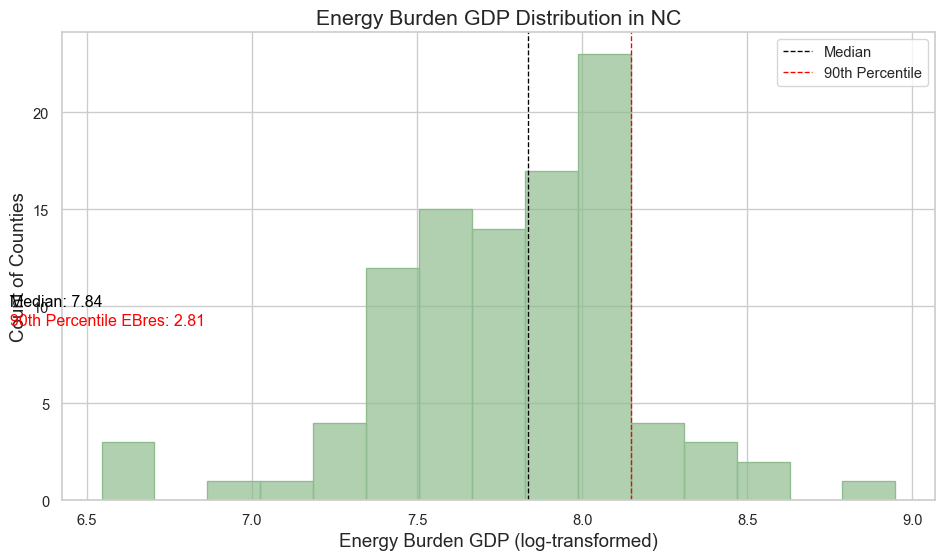

```
Median EBres: [1.79764853]
```

```python
state = "NC"

hist_plot = plot_energy_gdp_histogram(state, df2025btm)
if hist_plot:
    hist_plot.show()

print("Median EBres:", summary_EBres_2025.loc[summary_EBres_2025['state'] == state, 'median_ebres'].values)
```

```
NC BTM 2025
Pearson Correlation (Box-Cox): 0.397
Kendall Correlation (Raw): 0.278
```

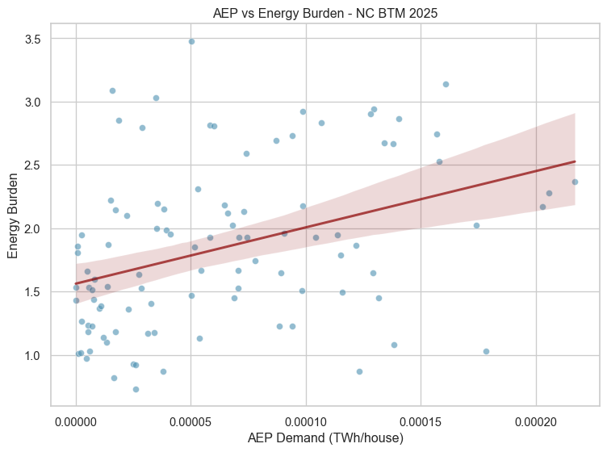

```
  state   pearson   kendall
0    NC  0.397242  0.277576
```

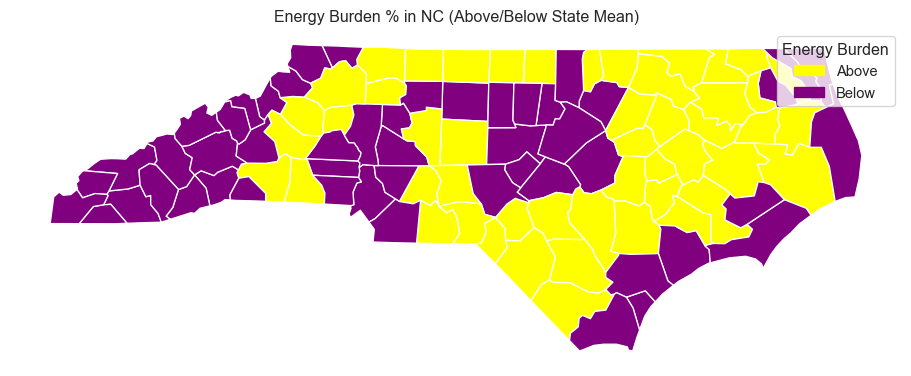

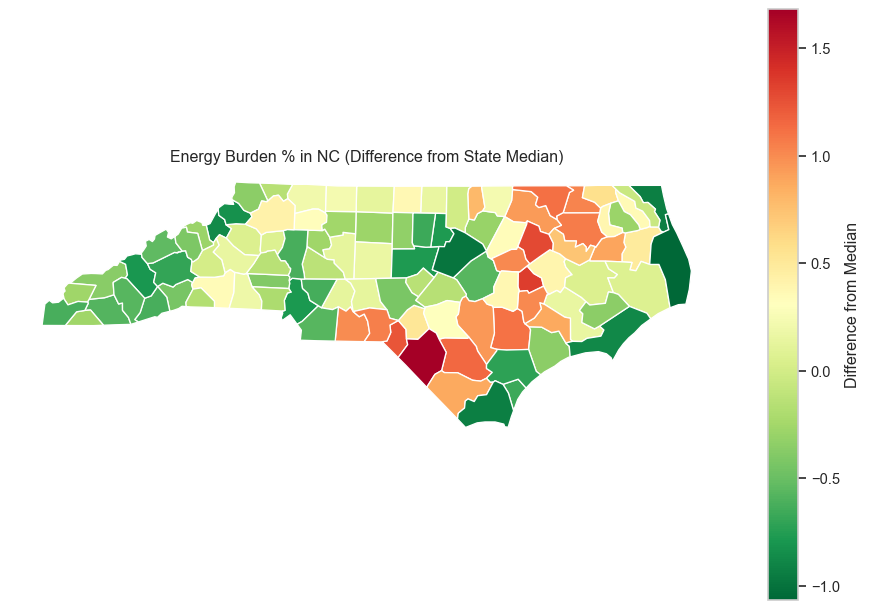

```python
corrNC_2025 = corrAEP_EB_State(df2025btm, 'BTM', '2025', state)
print(corrNC_2025)
EB_county_map_state(df2025btm, summary_EBres_2025, state_abbr=state)
```

Model without interactions

```
                            OLS Regression Results
==============================================================================
Dep. Variable:                  EBres   R-squared:                       0.735
Model:                            OLS   Adj. R-squared:                  0.724
Method:                 Least Squares   F-statistic:                     65.92
Date:                Thu, 16 Oct 2025   Prob (F-statistic):           1.41e-26
Time:                        10:38:31   Log-Likelihood:                -31.003
No. Observations:                 100   AIC:                             72.01
Df Residuals:                      95   BIC:                             85.03
Df Model:                           4
Covariance Type:            nonrobust
==============================================================================================
                                 coef    std err          t      P>|t|      [0.025      0.975]
----------------------------------------------------------------------------------------------
Intercept                      2.0020      0.284      7.046      0.000       1.438       2.566
UnemploymentRate              -0.1146      0.080     -1.439      0.153      -0.273       0.043
Q("Poverty%_standardized")     0.4762      0.062      7.632      0.000       0.352       0.600
AgricultureInd                 0.0242      0.007      3.423      0.001       0.010       0.038
NonWhite_standardized          0.2046      0.050      4.059      0.000       0.105       0.305
==============================================================================
Omnibus:                        0.535   Durbin-Watson:                   1.775
Prob(Omnibus):                  0.765   Jarque-Bera (JB):                0.680
Skew:                          -0.099   Prob(JB):                        0.712
Kurtosis:                       2.648   Cond. No.                         59.3
==============================================================================

Notes:
[1] Standard Errors assume that the covariance matrix of the errors is correctly specified.
```

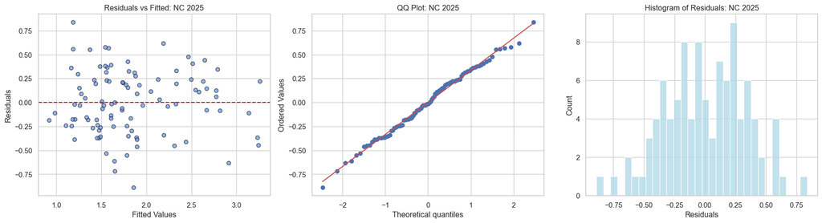

```
--- NC 2025 ---
Kolmogorov-Smirnov Test for Normality:
D = 0.0592 | p-value = 0.8538
Breusch-Pagan Test for Homoskedasticity:
Chi-Sq = 4.5317 | p-value = 0.3388
```

```python
lm_NC2025btm = lm_generation(df2025btm, state)
print(lm_NC2025btm.summary())
diagnostic_plots(lm_NC2025btm, f"{state} 2025")
```

Model with interactions

```
                            OLS Regression Results
==============================================================================
Dep. Variable:                  EBres   R-squared:                       0.800
Model:                            OLS   Adj. R-squared:                  0.778
Method:                 Least Squares   F-statistic:                     35.70
Date:                Thu, 16 Oct 2025   Prob (F-statistic):           6.09e-27
Time:                        10:38:32   Log-Likelihood:                -16.851
No. Observations:                 100   AIC:                             55.70
Df Residuals:                      89   BIC:                             84.36
Df Model:                          10
Covariance Type:            nonrobust
====================================================================================================================
                                                       coef    std err          t      P>|t|      [0.025      0.975]
--------------------------------------------------------------------------------------------------------------------
Intercept                                            1.5267      0.366      4.174      0.000       0.800       2.253
UnemploymentRate                                    -0.0027      0.105     -0.026      0.979      -0.210       0.205
Q("Poverty%_standardized")                           0.9169      0.241      3.800      0.000       0.437       1.396
AgricultureInd                                       0.1001      0.038      2.638      0.010       0.025       0.175
NonWhite_standardized                               -0.1489      0.343     -0.434      0.666      -0.831       0.533
UnemploymentRate:Q("Poverty%_standardized")         -0.1575      0.069     -2.298      0.024      -0.294      -0.021
UnemploymentRate:AgricultureInd                     -0.0111      0.009     -1.184      0.240      -0.030       0.008
UnemploymentRate:NonWhite_standardized               0.0959      0.096      1.000      0.320      -0.095       0.287
Q("Poverty%_standardized"):AgricultureInd           -0.0127      0.018     -0.703      0.484      -0.048       0.023
Q("Poverty%_standardized"):NonWhite_standardized     0.1582      0.062      2.541      0.013       0.034       0.282
AgricultureInd:NonWhite_standardized                -0.0140      0.019     -0.739      0.462      -0.052       0.024
==============================================================================
Omnibus:                        1.071   Durbin-Watson:                   1.807
Prob(Omnibus):                  0.585   Jarque-Bera (JB):                1.002
Skew:                          -0.052   Prob(JB):                        0.606
Kurtosis:                       2.521   Cond. No.                         427.
==============================================================================

Notes:
[1] Standard Errors assume that the covariance matrix of the errors is correctly specified.
```

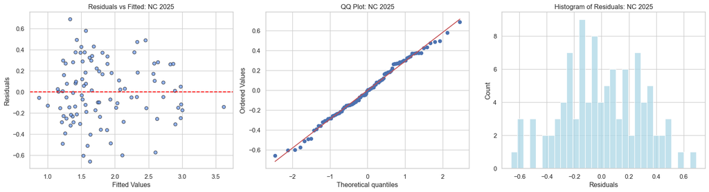

```
--- NC 2025 ---
Kolmogorov-Smirnov Test for Normality:
D = 0.0702 | p-value = 0.6819
Breusch-Pagan Test for Homoskedasticity:
Chi-Sq = 13.5024 | p-value = 0.1969
```

```python
lm_NC2025btm_int = lm_generation_interactions(df2025btm, state)
print(lm_NC2025btm_int.summary())
diagnostic_plots(lm_NC2025btm_int, f"{state} 2025")
```

##### 2035

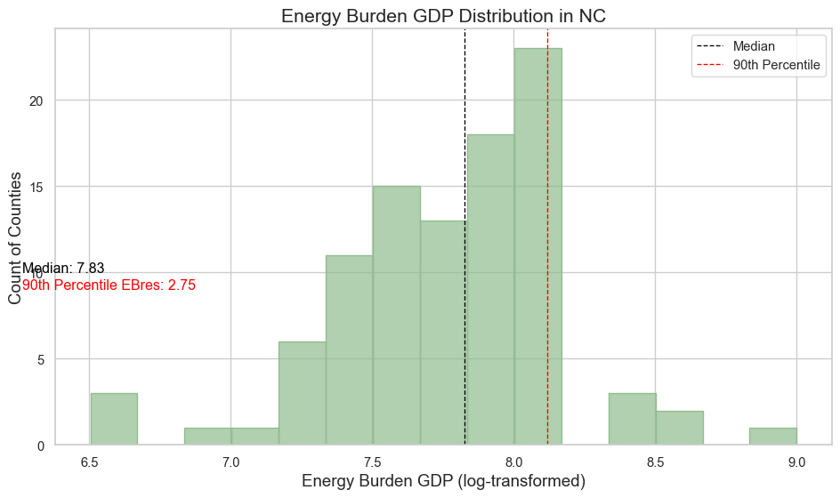

```
Median EBres: [1.80771281]
```

```python
state = "NC"

hist_plot = plot_energy_gdp_histogram(state, df2035btm)
if hist_plot:
    hist_plot.show()

print("Median EBres:", summary_EBres_2035.loc[summary_EBres_2035['state'] == state, 'median_ebres'].values)
```

```
NC BTM 2035
Pearson Correlation (Box-Cox): 0.410
Kendall Correlation (Raw): 0.288
```

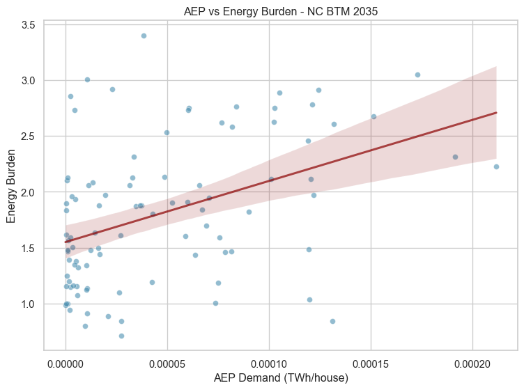

```
  state   pearson   kendall
0    NC  0.409683  0.287719
```

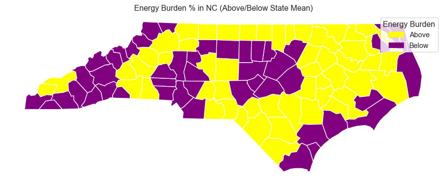

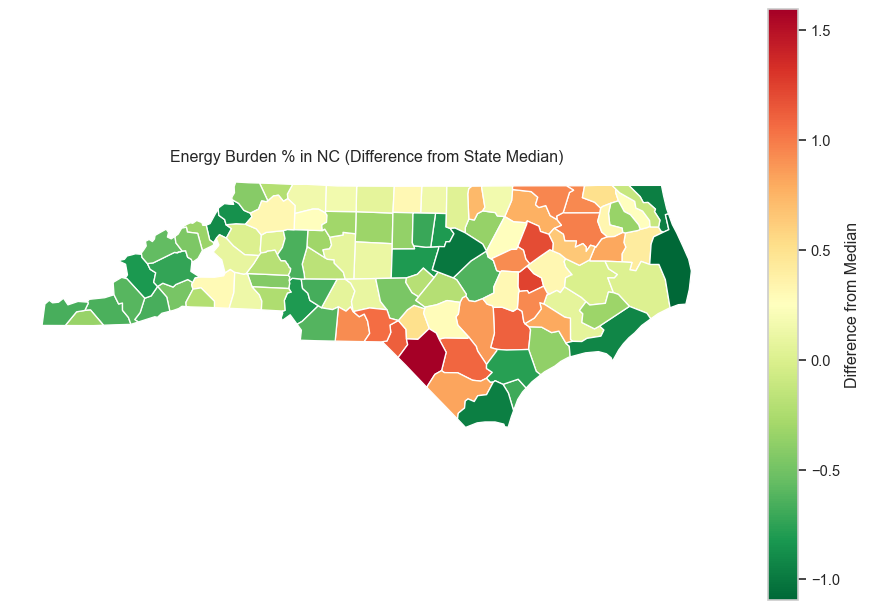

```python
corrNC_2035 = corrAEP_EB_State(df2035btm, 'BTM', '2035', state)
print(corrNC_2035)
EB_county_map_state(df2035btm, summary_EBres_2035, state_abbr=state)
```

Model without interactions

```
                            OLS Regression Results
==============================================================================
Dep. Variable:                  EBres   R-squared:                       0.740
Model:                            OLS   Adj. R-squared:                  0.729
Method:                 Least Squares   F-statistic:                     65.63
Date:                Thu, 16 Oct 2025   Prob (F-statistic):           3.95e-26
Time:                        10:38:34   Log-Likelihood:                -27.926
No. Observations:                  97   AIC:                             65.85
Df Residuals:                      92   BIC:                             78.73
Df Model:                           4
Covariance Type:            nonrobust
==============================================================================================
                                 coef    std err          t      P>|t|      [0.025      0.975]
----------------------------------------------------------------------------------------------
Intercept                      2.0393      0.281      7.258      0.000       1.481       2.597
UnemploymentRate              -0.1355      0.078     -1.727      0.088      -0.291       0.020
Q("Poverty%_standardized")     0.4723      0.062      7.606      0.000       0.349       0.596
AgricultureInd                 0.0242      0.007      3.480      0.001       0.010       0.038
NonWhite_standardized          0.2072      0.050      4.110      0.000       0.107       0.307
==============================================================================
Omnibus:                        0.482   Durbin-Watson:                   1.718
Prob(Omnibus):                  0.786   Jarque-Bera (JB):                0.637
Skew:                          -0.118   Prob(JB):                        0.727
Kurtosis:                       2.680   Cond. No.                         59.8
==============================================================================

Notes:
[1] Standard Errors assume that the covariance matrix of the errors is correctly specified.
```

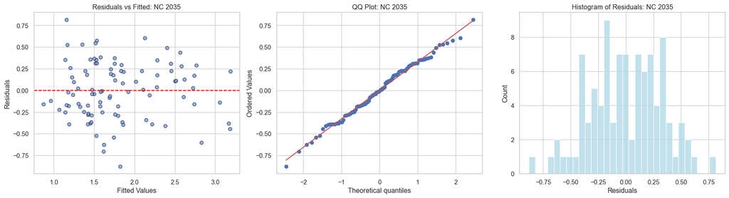

```
--- NC 2035 ---
Kolmogorov-Smirnov Test for Normality:
D = 0.0628 | p-value = 0.8162
Breusch-Pagan Test for Homoskedasticity:
Chi-Sq = 4.0018 | p-value = 0.4058
```

```python
lm_NC2035btm = lm_generation(df2035btm, state)
print(lm_NC2035btm.summary())
diagnostic_plots(lm_NC2035btm, f"{state} 2035")
```

Model with interactions

```
                            OLS Regression Results
==============================================================================
Dep. Variable:                  EBres   R-squared:                       0.803
Model:                            OLS   Adj. R-squared:                  0.781
Method:                 Least Squares   F-statistic:                     35.16
Date:                Thu, 16 Oct 2025   Prob (F-statistic):           3.16e-26
Time:                        10:38:34   Log-Likelihood:                -14.448
No. Observations:                  97   AIC:                             50.90
Df Residuals:                      86   BIC:                             79.22
Df Model:                          10
Covariance Type:            nonrobust
====================================================================================================================
                                                       coef    std err          t      P>|t|      [0.025      0.975]
--------------------------------------------------------------------------------------------------------------------
Intercept                                            1.5266      0.363      4.205      0.000       0.805       2.248
UnemploymentRate                                    -0.0127      0.103     -0.122      0.903      -0.218       0.193
Q("Poverty%_standardized")                           0.9093      0.238      3.818      0.000       0.436       1.383
AgricultureInd                                       0.0982      0.038      2.615      0.011       0.024       0.173
NonWhite_standardized                               -0.0898      0.340     -0.264      0.792      -0.766       0.586
UnemploymentRate:Q("Poverty%_standardized")         -0.1558      0.067     -2.309      0.023      -0.290      -0.022
UnemploymentRate:AgricultureInd                     -0.0107      0.009     -1.161      0.249      -0.029       0.008
UnemploymentRate:NonWhite_standardized               0.0819      0.095      0.864      0.390      -0.107       0.270
Q("Poverty%_standardized"):AgricultureInd           -0.0114      0.018     -0.643      0.522      -0.047       0.024
Q("Poverty%_standardized"):NonWhite_standardized     0.1521      0.062      2.459      0.016       0.029       0.275
AgricultureInd:NonWhite_standardized                -0.0149      0.019     -0.798      0.427      -0.052       0.022
==============================================================================
Omnibus:                        0.525   Durbin-Watson:                   1.806
Prob(Omnibus):                  0.769   Jarque-Bera (JB):                0.651
Skew:                          -0.030   Prob(JB):                        0.722
Kurtosis:                       2.603   Cond. No.                         431.
==============================================================================

Notes:
[1] Standard Errors assume that the covariance matrix of the errors is correctly specified.
```

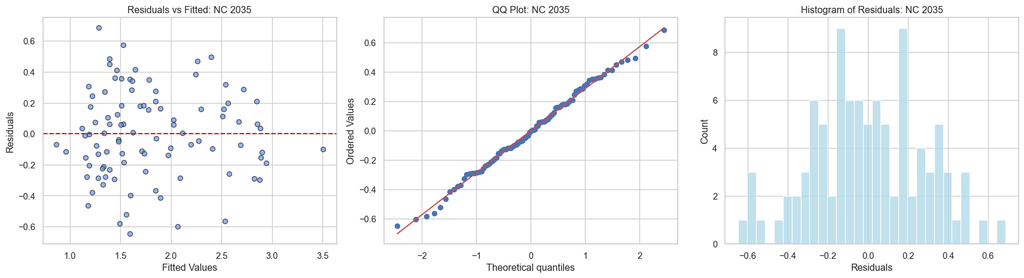

```
--- NC 2035 ---
Kolmogorov-Smirnov Test for Normality:
D = 0.0409 | p-value = 0.9949
Breusch-Pagan Test for Homoskedasticity:
Chi-Sq = 11.3495 | p-value = 0.3309
```

```python
lm_NC2035btm_int = lm_generation_interactions(df2035btm, state)
print(lm_NC2035btm_int.summary())
diagnostic_plots(lm_NC2035btm_int, f"{state} 2035")
```

#### Georgia

##### 2025

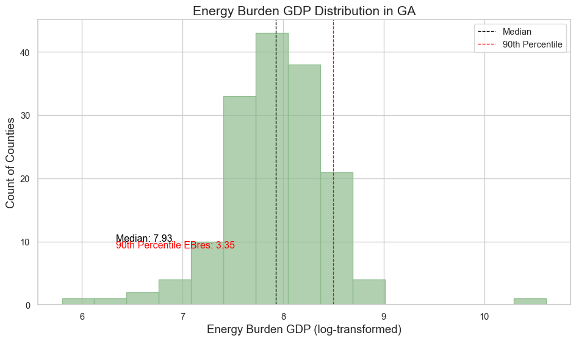

```
Median EBres: [2.31072886]
```

```python
state = "GA"

hist_plot = plot_energy_gdp_histogram(state, df2025btm)
if hist_plot:
    hist_plot.show()

print("Median EBres:", summary_EBres_2025.loc[summary_EBres_2025['state'] == state, 'median_ebres'].values)
```

```
GA BTM 2025
Pearson Correlation (Box-Cox): 0.489
Kendall Correlation (Raw): 0.355
```

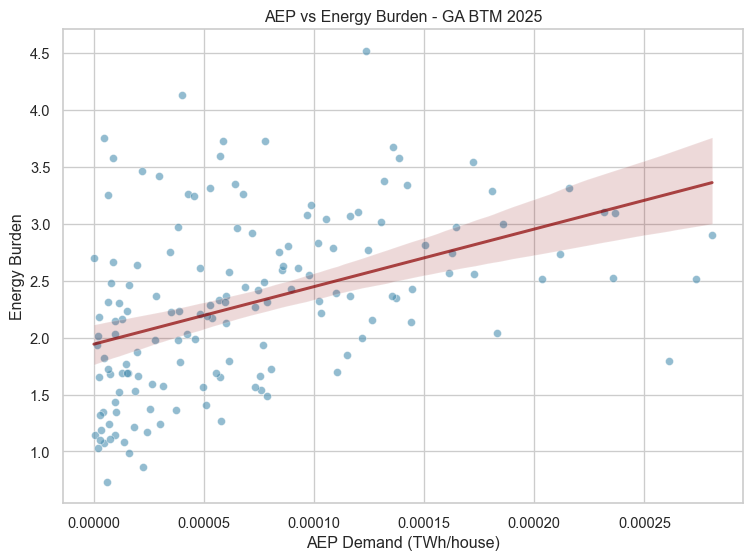

```
  state   pearson   kendall
0    GA  0.489346  0.354833
```

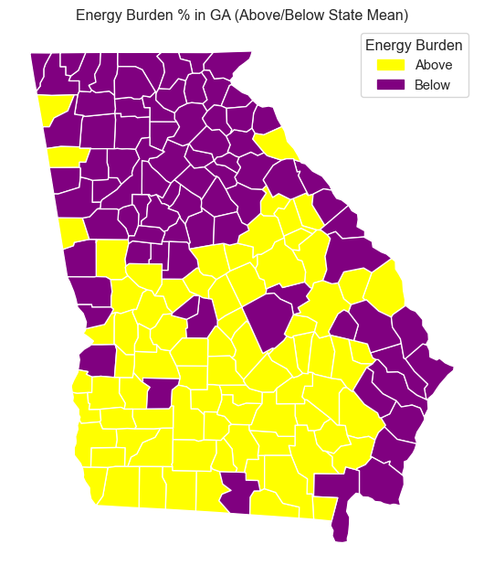

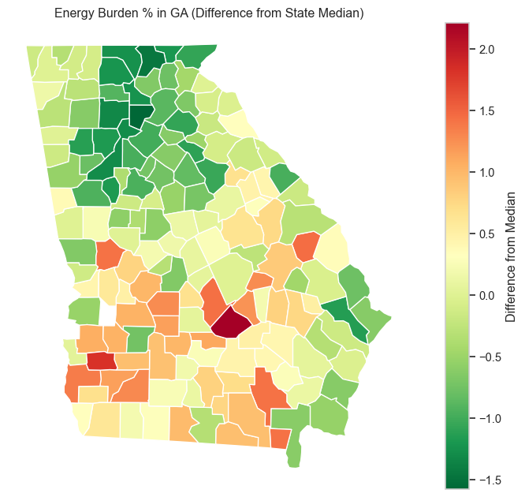

```python
corrGA_2025 = corrAEP_EB_State(df2025btm, 'BTM', '2025', state)
print(corrGA_2025)
EB_county_map_state(df2025btm, summary_EBres_2025, state_abbr=state)
```

Model without interactions

```
                            OLS Regression Results
==============================================================================
Dep. Variable:                  EBres   R-squared:                       0.660
Model:                            OLS   Adj. R-squared:                  0.651
Method:                 Least Squares   F-statistic:                     73.88
Date:                Thu, 16 Oct 2025   Prob (F-statistic):           1.17e-34
Time:                        10:38:36   Log-Likelihood:                -95.411
No. Observations:                 157   AIC:                             200.8
Df Residuals:                     152   BIC:                             216.1
Df Model:                           4
Covariance Type:            nonrobust
==============================================================================================
                                 coef    std err          t      P>|t|      [0.025      0.975]
----------------------------------------------------------------------------------------------
Intercept                      1.6944      0.221      7.680      0.000       1.259       2.130
UnemploymentRate               0.0811      0.065      1.240      0.217      -0.048       0.210
Q("Poverty%_standardized")     0.4900      0.045     11.001      0.000       0.402       0.578
AgricultureInd                 0.0130      0.007      1.972      0.050   -2.49e-05       0.026
NonWhite_standardized         -0.1034      0.050     -2.069      0.040      -0.202      -0.005
==============================================================================
Omnibus:                       20.729   Durbin-Watson:                   1.888
Prob(Omnibus):                  0.000   Jarque-Bera (JB):               34.367
Skew:                          -0.668   Prob(JB):                     3.45e-08
Kurtosis:                       4.862   Cond. No.                         54.7
==============================================================================

Notes:
[1] Standard Errors assume that the covariance matrix of the errors is correctly specified.
```

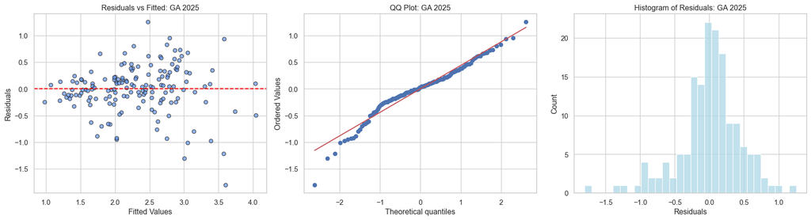

```
--- GA 2025 ---
Kolmogorov-Smirnov Test for Normality:
D = 0.1026 | p-value = 0.0682
Breusch-Pagan Test for Homoskedasticity:
Chi-Sq = 21.4346 | p-value = 0.0003
```

```python
lm_GA2025btm = lm_generation(df2025btm, state)
print(lm_GA2025btm.summary())
diagnostic_plots(lm_GA2025btm, f"{state} 2025")
```

Model with interactions

```
                            OLS Regression Results
==============================================================================
Dep. Variable:                  EBres   R-squared:                       0.696
Model:                            OLS   Adj. R-squared:                  0.675
Method:                 Least Squares   F-statistic:                     33.36
Date:                Thu, 16 Oct 2025   Prob (F-statistic):           6.40e-33
Time:                        10:38:36   Log-Likelihood:                -86.818
No. Observations:                 157   AIC:                             195.6
Df Residuals:                     146   BIC:                             229.3
Df Model:                          10
Covariance Type:            nonrobust
====================================================================================================================
                                                       coef    std err          t      P>|t|      [0.025      0.975]
--------------------------------------------------------------------------------------------------------------------
Intercept                                            1.2511      0.418      2.993      0.003       0.425       2.077
UnemploymentRate                                     0.2198      0.127      1.727      0.086      -0.032       0.471
Q("Poverty%_standardized")                           0.4767      0.221      2.155      0.033       0.040       0.914
AgricultureInd                                       0.0248      0.040      0.612      0.542      -0.055       0.105
NonWhite_standardized                                0.4770      0.388      1.228      0.221      -0.291       1.245
UnemploymentRate:Q("Poverty%_standardized")          0.0335      0.066      0.505      0.614      -0.098       0.165
UnemploymentRate:AgricultureInd                     -0.0029      0.012     -0.232      0.817      -0.027       0.022
UnemploymentRate:NonWhite_standardized              -0.1693      0.111     -1.522      0.130      -0.389       0.051
Q("Poverty%_standardized"):AgricultureInd           -0.0150      0.006     -2.488      0.014      -0.027      -0.003
Q("Poverty%_standardized"):NonWhite_standardized    -0.0617      0.072     -0.861      0.391      -0.203       0.080
AgricultureInd:NonWhite_standardized                 0.0223      0.014      1.621      0.107      -0.005       0.049
==============================================================================
Omnibus:                       14.703   Durbin-Watson:                   1.882
Prob(Omnibus):                  0.001   Jarque-Bera (JB):               18.566
Skew:                          -0.594   Prob(JB):                     9.30e-05
Kurtosis:                       4.195   Cond. No.                         573.
==============================================================================

Notes:
[1] Standard Errors assume that the covariance matrix of the errors is correctly specified.
```

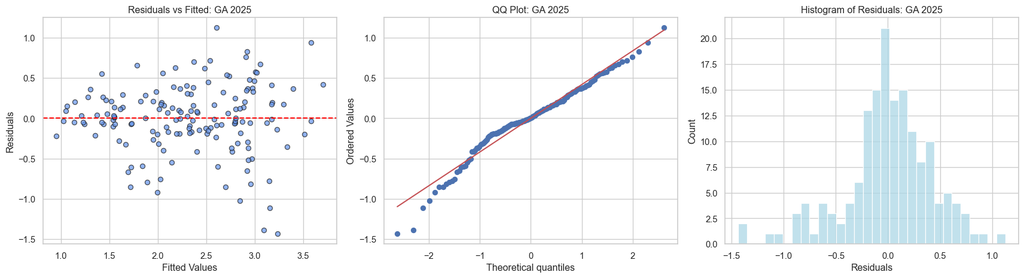

```
--- GA 2025 ---
Kolmogorov-Smirnov Test for Normality:
D = 0.1008 | p-value = 0.0769
Breusch-Pagan Test for Homoskedasticity:
Chi-Sq = 24.8277 | p-value = 0.0057
```

```python
lm_GA2025btm_int = lm_generation_interactions(df2025btm, state)
print(lm_GA2025btm_int.summary())
diagnostic_plots(lm_GA2025btm_int, f"{state} 2025")
```

##### 2035

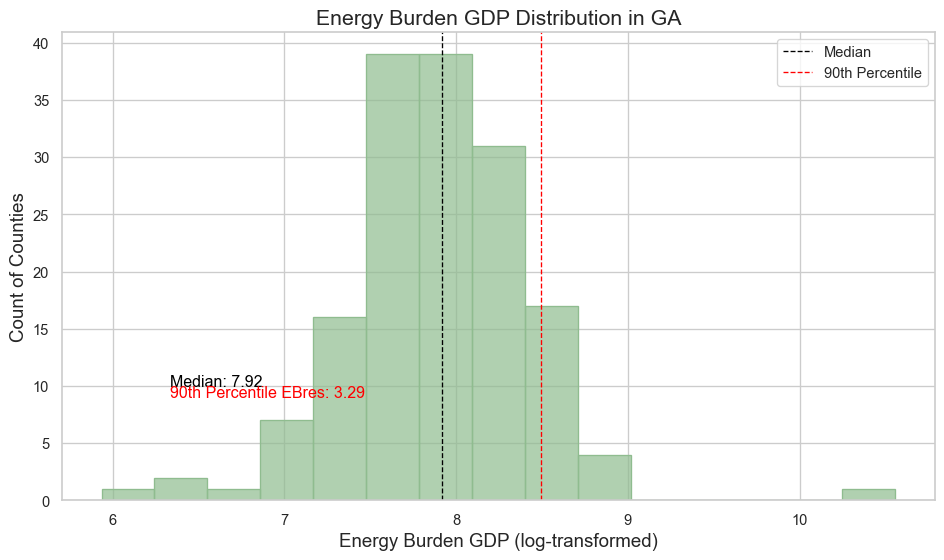

```
Median EBres: [2.24179414]
```

```python
state = "GA"

hist_plot = plot_energy_gdp_histogram(state, df2035btm)
if hist_plot:
    hist_plot.show()

print("Median EBres:", summary_EBres_2035.loc[summary_EBres_2035['state'] == state, 'median_ebres'].values)
```

```
GA BTM 2035
Pearson Correlation (Box-Cox): 0.502
Kendall Correlation (Raw): 0.364
```

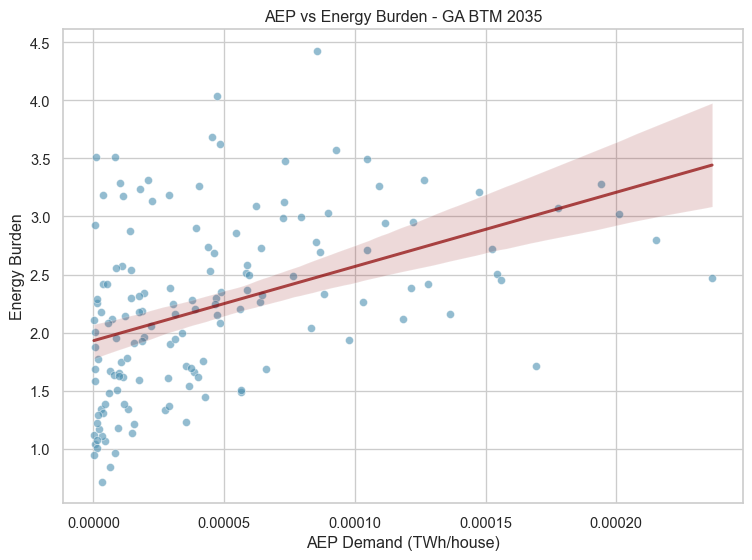

```
  state   pearson   kendall
0    GA  0.502011  0.363854
```

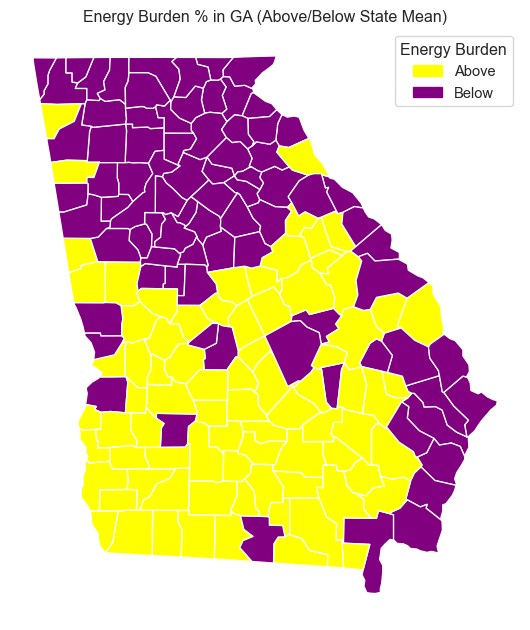

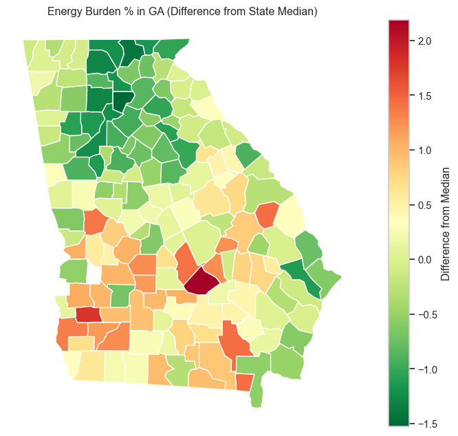

```python
corrGA_2035 = corrAEP_EB_State(df2035btm, 'BTM', '2035', state)
print(corrGA_2035)
EB_county_map_state(df2035btm, summary_EBres_2035, state_abbr=state)
```

Model without interactions

```
                            OLS Regression Results
==============================================================================
Dep. Variable:                  EBres   R-squared:                       0.648
Model:                            OLS   Adj. R-squared:                  0.638
Method:                 Least Squares   F-statistic:                     69.82
Date:                Thu, 16 Oct 2025   Prob (F-statistic):           1.91e-33
Time:                        10:38:38   Log-Likelihood:                -96.326
No. Observations:                 157   AIC:                             202.7
Df Residuals:                     152   BIC:                             217.9
Df Model:                           4
Covariance Type:            nonrobust
==============================================================================================
                                 coef    std err          t      P>|t|      [0.025      0.975]
----------------------------------------------------------------------------------------------
Intercept                      1.5483      0.222      6.979      0.000       1.110       1.987
UnemploymentRate               0.1108      0.066      1.683      0.094      -0.019       0.241
Q("Poverty%_standardized")     0.4689      0.045     10.445      0.000       0.380       0.558
AgricultureInd                 0.0131      0.007      1.970      0.051   -3.71e-05       0.026
NonWhite_standardized         -0.1026      0.050     -2.038      0.043      -0.202      -0.003
==============================================================================
Omnibus:                       18.270   Durbin-Watson:                   1.901
Prob(Omnibus):                  0.000   Jarque-Bera (JB):               29.707
Skew:                          -0.600   Prob(JB):                     3.54e-07
Kurtosis:                       4.762   Cond. No.                         54.7
==============================================================================

Notes:
[1] Standard Errors assume that the covariance matrix of the errors is correctly specified.
```

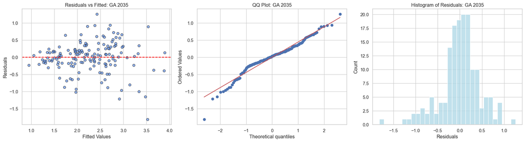

```
--- GA 2035 ---
Kolmogorov-Smirnov Test for Normality:
D = 0.1021 | p-value = 0.0707
Breusch-Pagan Test for Homoskedasticity:
Chi-Sq = 21.9542 | p-value = 0.0002
```

```python
lm_GA2035btm = lm_generation(df2035btm, state)
print(lm_GA2035btm.summary())
diagnostic_plots(lm_GA2035btm, f"{state} 2035")
```

Model with interactions

```
                            OLS Regression Results
==============================================================================
Dep. Variable:                  EBres   R-squared:                       0.681
Model:                            OLS   Adj. R-squared:                  0.659
Method:                 Least Squares   F-statistic:                     31.14
Date:                Thu, 16 Oct 2025   Prob (F-statistic):           1.87e-31
Time:                        10:38:38   Log-Likelihood:                -88.550
No. Observations:                 157   AIC:                             199.1
Df Residuals:                     146   BIC:                             232.7
Df Model:                          10
Covariance Type:            nonrobust
====================================================================================================================
                                                       coef    std err          t      P>|t|      [0.025      0.975]
--------------------------------------------------------------------------------------------------------------------
Intercept                                            1.0622      0.425      2.502      0.013       0.223       1.901
UnemploymentRate                                     0.2665      0.129      2.062      0.041       0.011       0.522
Q("Poverty%_standardized")                           0.5001      0.224      2.232      0.027       0.057       0.943
AgricultureInd                                       0.0393      0.041      0.961      0.338      -0.042       0.120
NonWhite_standardized                                0.3674      0.393      0.934      0.352      -0.410       1.145
UnemploymentRate:Q("Poverty%_standardized")          0.0200      0.067      0.297      0.767      -0.113       0.153
UnemploymentRate:AgricultureInd                     -0.0084      0.013     -0.670      0.504      -0.033       0.016
UnemploymentRate:NonWhite_standardized              -0.1402      0.113     -1.245      0.215      -0.363       0.082
Q("Poverty%_standardized"):AgricultureInd           -0.0134      0.006     -2.196      0.030      -0.026      -0.001
Q("Poverty%_standardized"):NonWhite_standardized    -0.0729      0.073     -1.002      0.318      -0.217       0.071
AgricultureInd:NonWhite_standardized                 0.0253      0.014      1.821      0.071      -0.002       0.053
==============================================================================
Omnibus:                       10.350   Durbin-Watson:                   1.915
Prob(Omnibus):                  0.006   Jarque-Bera (JB):               11.317
Skew:                          -0.502   Prob(JB):                      0.00349
Kurtosis:                       3.849   Cond. No.                         575.
==============================================================================

Notes:
[1] Standard Errors assume that the covariance matrix of the errors is correctly specified.
```

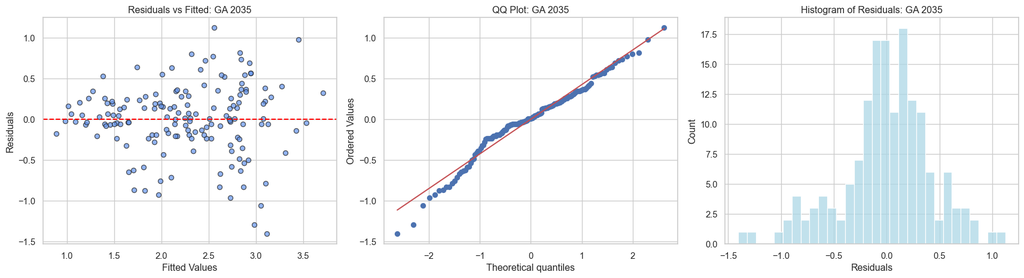

```
--- GA 2035 ---
Kolmogorov-Smirnov Test for Normality:
D = 0.0996 | p-value = 0.0828
Breusch-Pagan Test for Homoskedasticity:
Chi-Sq = 25.2220 | p-value = 0.0049
```

```python
lm_GA2035btm_int = lm_generation_interactions(df2035btm, state)
print(lm_GA2035btm_int.summary())
diagnostic_plots(lm_GA2035btm_int, f"{state} 2035")
```

#### Iowa

##### 2025

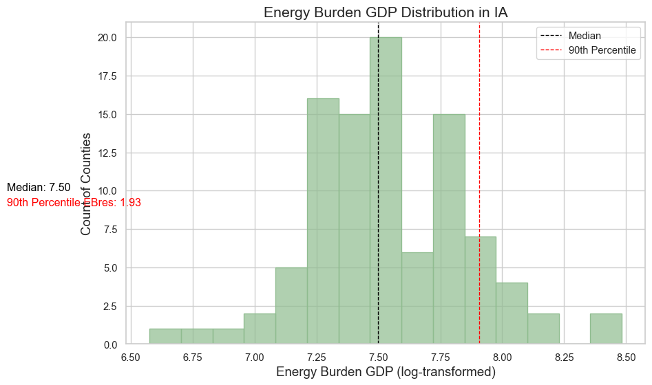

```
Median EBres: [1.54285544]
```

```python
state = "IA"

hist_plot = plot_energy_gdp_histogram(state, df2025btm)
if hist_plot:
    hist_plot.show()

print("Median EBres:", summary_EBres_2025.loc[summary_EBres_2025['state'] == state, 'median_ebres'].values)
```

```
IA BTM 2025
Pearson Correlation (Box-Cox): 0.407
Kendall Correlation (Raw): 0.253
```

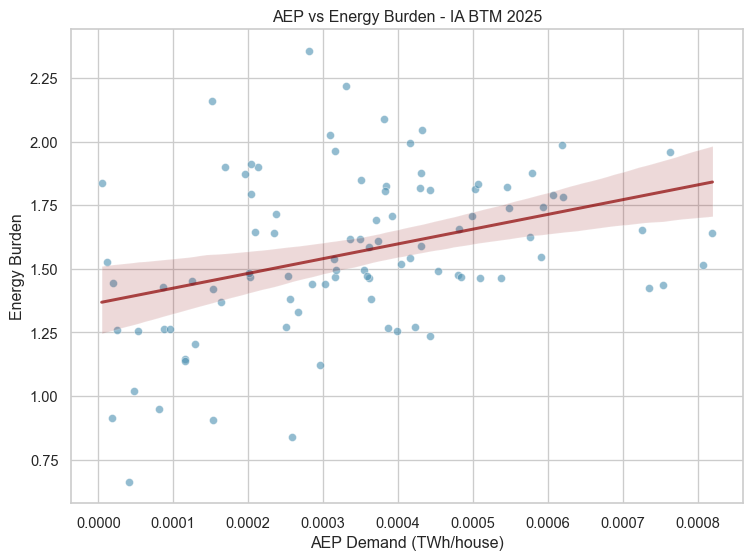

```
  state  pearson   kendall
0    IA  0.40689  0.252856
```

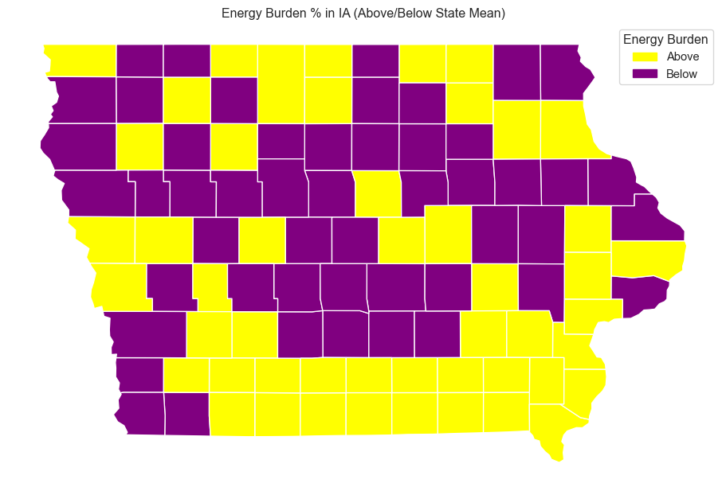

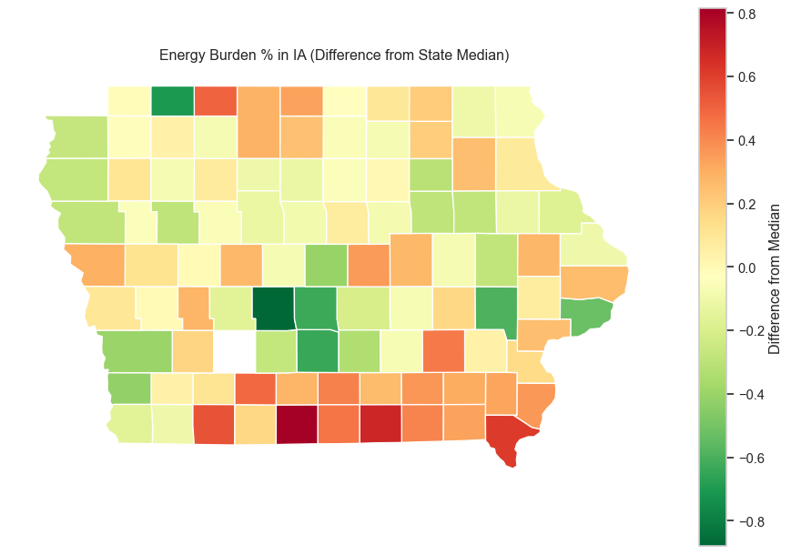

```python
corrIA_2025 = corrAEP_EB_State(df2025btm, 'BTM', '2025', state)
print(corrIA_2025)
EB_county_map_state(df2025btm, summary_EBres_2025, state_abbr=state)
```

Model without interactions

```
                            OLS Regression Results
==============================================================================
Dep. Variable:                  EBres   R-squared:                       0.421
Model:                            OLS   Adj. R-squared:                  0.396
Method:                 Least Squares   F-statistic:                     16.72
Date:                Thu, 16 Oct 2025   Prob (F-statistic):           2.47e-10
Time:                        10:38:40   Log-Likelihood:                 2.9247
No. Observations:                  97   AIC:                             4.151
Df Residuals:                      92   BIC:                             17.02
Df Model:                           4
Covariance Type:            nonrobust
==============================================================================================
                                 coef    std err          t      P>|t|      [0.025      0.975]
----------------------------------------------------------------------------------------------
Intercept                      1.0670      0.166      6.410      0.000       0.736       1.398
UnemploymentRate               0.1652      0.046      3.599      0.001       0.074       0.256
Q("Poverty%_standardized")     0.3759      0.058      6.504      0.000       0.261       0.491
AgricultureInd                 0.0072      0.003      2.865      0.005       0.002       0.012
NonWhite_standardized         -0.2354      0.066     -3.588      0.001      -0.366      -0.105
==============================================================================
Omnibus:                        0.890   Durbin-Watson:                   2.001
Prob(Omnibus):                  0.641   Jarque-Bera (JB):                1.002
Skew:                          -0.193   Prob(JB):                        0.606
Kurtosis:                       2.685   Cond. No.                         130.
==============================================================================

Notes:
[1] Standard Errors assume that the covariance matrix of the errors is correctly specified.
```

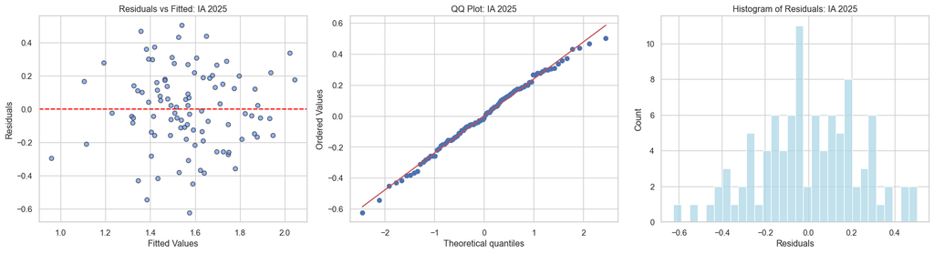

```
--- IA 2025 ---
Kolmogorov-Smirnov Test for Normality:
D = 0.0396 | p-value = 0.9966
Breusch-Pagan Test for Homoskedasticity:
Chi-Sq = 20.9405 | p-value = 0.0003
```

```python
lm_IA2025btm = lm_generation(df2025btm, state)
print(lm_IA2025btm.summary())
diagnostic_plots(lm_IA2025btm, f"{state} 2025")
```

Model with interactions

```
                            OLS Regression Results
==============================================================================
Dep. Variable:                  EBres   R-squared:                       0.504
Model:                            OLS   Adj. R-squared:                  0.446
Method:                 Least Squares   F-statistic:                     8.735
Date:                Thu, 16 Oct 2025   Prob (F-statistic):           1.02e-09
Time:                        10:38:40   Log-Likelihood:                 10.419
No. Observations:                  97   AIC:                             1.162
Df Residuals:                      86   BIC:                             29.48
Df Model:                          10
Covariance Type:            nonrobust
====================================================================================================================
                                                       coef    std err          t      P>|t|      [0.025      0.975]
--------------------------------------------------------------------------------------------------------------------
Intercept                                            0.5614      0.285      1.970      0.052      -0.005       1.128
UnemploymentRate                                     0.2660      0.088      3.031      0.003       0.092       0.441
Q("Poverty%_standardized")                           0.3013      0.366      0.824      0.412      -0.426       1.029
AgricultureInd                                       0.0273      0.017      1.647      0.103      -0.006       0.060
NonWhite_standardized                               -0.8850      0.274     -3.234      0.002      -1.429      -0.341
UnemploymentRate:Q("Poverty%_standardized")         -0.0184      0.131     -0.140      0.889      -0.279       0.242
UnemploymentRate:AgricultureInd                     -0.0058      0.005     -1.184      0.240      -0.015       0.004
UnemploymentRate:NonWhite_standardized               0.0865      0.074      1.173      0.244      -0.060       0.233
Q("Poverty%_standardized"):AgricultureInd           -0.0110      0.007     -1.670      0.099      -0.024       0.002
Q("Poverty%_standardized"):NonWhite_standardized    -0.3002      0.218     -1.377      0.172      -0.734       0.133
AgricultureInd:NonWhite_standardized                 0.0164      0.007      2.322      0.023       0.002       0.031
==============================================================================
Omnibus:                        0.820   Durbin-Watson:                   1.867
Prob(Omnibus):                  0.664   Jarque-Bera (JB):                0.937
Skew:                           0.187   Prob(JB):                        0.626
Kurtosis:                       2.697   Cond. No.                     1.01e+03
==============================================================================

Notes:
[1] Standard Errors assume that the covariance matrix of the errors is correctly specified.
[2] The condition number is large, 1.01e+03. This might indicate that there are
strong multicollinearity or other numerical problems.
```

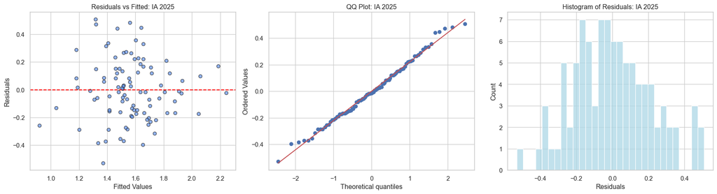

```
--- IA 2025 ---
Kolmogorov-Smirnov Test for Normality:
D = 0.0502 | p-value = 0.9570
Breusch-Pagan Test for Homoskedasticity:
Chi-Sq = 21.9112 | p-value = 0.0156
```

```python
lm_IA2025btm_int = lm_generation_interactions(df2025btm, state)
print(lm_IA2025btm_int.summary())
diagnostic_plots(lm_IA2025btm_int, f"{state} 2025")
```

##### 2035

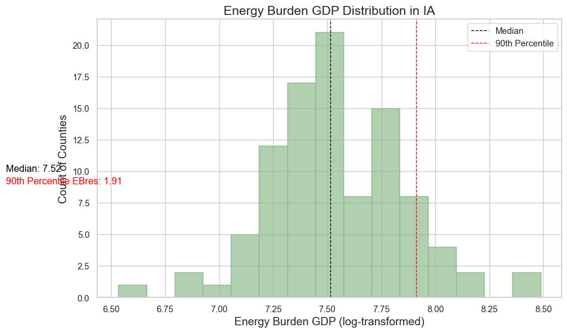

```
Median EBres: [1.53839366]
```

```python
state = "IA"

hist_plot = plot_energy_gdp_histogram(state, df2035btm)
if hist_plot:
    hist_plot.show()

print("Median EBres:", summary_EBres_2035.loc[summary_EBres_2035['state'] == state, 'median_ebres'].values)
```

```
IA BTM 2035
Pearson Correlation (Box-Cox): 0.413
Kendall Correlation (Raw): 0.262
```

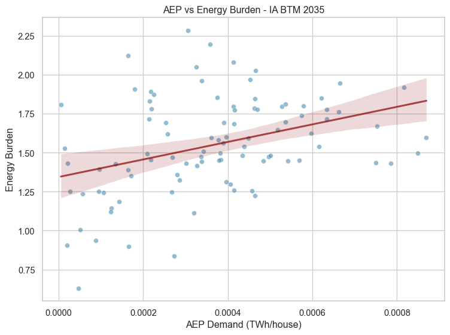

```
  state   pearson   kendall
0    IA  0.412872  0.262262
```

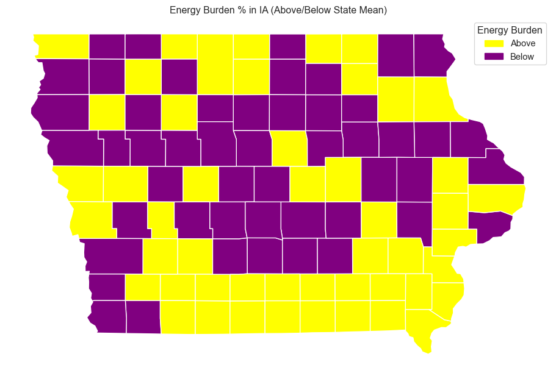

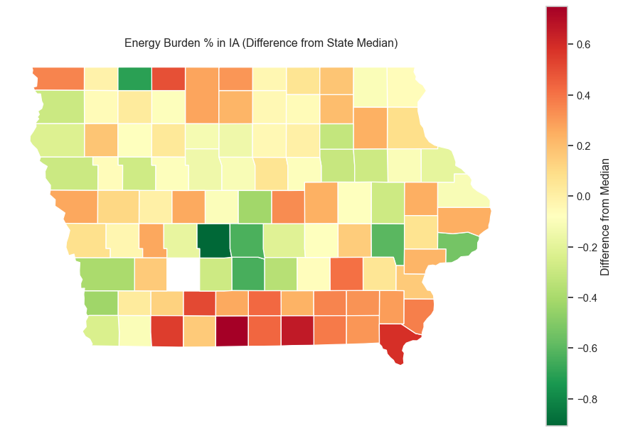

```python
corrIA_2035 = corrAEP_EB_State(df2035btm, 'BTM', '2035', state)
print(corrIA_2035)
EB_county_map_state(df2035btm, summary_EBres_2035, state_abbr=state)
```

Model without interactions

```
                            OLS Regression Results
==============================================================================
Dep. Variable:                  EBres   R-squared:                       0.403
Model:                            OLS   Adj. R-squared:                  0.377
Method:                 Least Squares   F-statistic:                     15.67
Date:                Thu, 16 Oct 2025   Prob (F-statistic):           7.82e-10
Time:                        10:38:43   Log-Likelihood:                 2.1954
No. Observations:                  98   AIC:                             5.609
Df Residuals:                      93   BIC:                             18.53
Df Model:                           4
Covariance Type:            nonrobust
==============================================================================================
                                 coef    std err          t      P>|t|      [0.025      0.975]
----------------------------------------------------------------------------------------------
Intercept                      1.0580      0.168      6.315      0.000       0.725       1.391
UnemploymentRate               0.1598      0.046      3.460      0.001       0.068       0.252
Q("Poverty%_standardized")     0.3630      0.058      6.237      0.000       0.247       0.479
AgricultureInd                 0.0078      0.003      3.098      0.003       0.003       0.013
NonWhite_standardized         -0.2337      0.066     -3.530      0.001      -0.365      -0.102
==============================================================================
Omnibus:                        0.876   Durbin-Watson:                   1.969
Prob(Omnibus):                  0.645   Jarque-Bera (JB):                0.953
Skew:                          -0.131   Prob(JB):                        0.621
Kurtosis:                       2.595   Cond. No.                         132.
==============================================================================

Notes:
[1] Standard Errors assume that the covariance matrix of the errors is correctly specified.
```

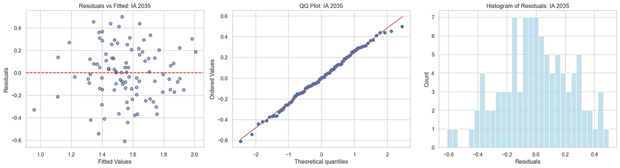

```
--- IA 2035 ---
Kolmogorov-Smirnov Test for Normality:
D = 0.0368 | p-value = 0.9988
Breusch-Pagan Test for Homoskedasticity:
Chi-Sq = 17.5775 | p-value = 0.0015
```

```python
lm_IA2035btm = lm_generation(df2035btm, state)
print(lm_IA2035btm.summary())
diagnostic_plots(lm_IA2035btm, f"{state} 2035")
```

Model with interactions

```
                            OLS Regression Results
==============================================================================
Dep. Variable:                  EBres   R-squared:                       0.498
Model:                            OLS   Adj. R-squared:                  0.440
Method:                 Least Squares   F-statistic:                     8.629
Date:                Thu, 16 Oct 2025   Prob (F-statistic):           1.21e-09
Time:                        10:38:43   Log-Likelihood:                 10.720
No. Observations:                  98   AIC:                            0.5606
Df Residuals:                      87   BIC:                             29.00
Df Model:                          10
Covariance Type:            nonrobust
====================================================================================================================
                                                       coef    std err          t      P>|t|      [0.025      0.975]
--------------------------------------------------------------------------------------------------------------------
Intercept                                            0.5314      0.283      1.875      0.064      -0.032       1.095
UnemploymentRate                                     0.2755      0.087      3.163      0.002       0.102       0.449
Q("Poverty%_standardized")                           0.3193      0.365      0.874      0.385      -0.407       1.046
AgricultureInd                                       0.0284      0.016      1.726      0.088      -0.004       0.061
NonWhite_standardized                               -0.8837      0.273     -3.233      0.002      -1.427      -0.340
UnemploymentRate:Q("Poverty%_standardized")         -0.0155      0.131     -0.119      0.905      -0.275       0.244
UnemploymentRate:AgricultureInd                     -0.0066      0.005     -1.369      0.175      -0.016       0.003
UnemploymentRate:NonWhite_standardized               0.0893      0.074      1.214      0.228      -0.057       0.235
Q("Poverty%_standardized"):AgricultureInd           -0.0134      0.006     -2.134      0.036      -0.026      -0.001
Q("Poverty%_standardized"):NonWhite_standardized    -0.2850      0.218     -1.306      0.195      -0.719       0.149
AgricultureInd:NonWhite_standardized                 0.0165      0.007      2.337      0.022       0.002       0.031
==============================================================================
Omnibus:                        0.893   Durbin-Watson:                   1.846
Prob(Omnibus):                  0.640   Jarque-Bera (JB):                1.006
Skew:                           0.184   Prob(JB):                        0.605
Kurtosis:                       2.668   Cond. No.                     1.02e+03
==============================================================================

Notes:
[1] Standard Errors assume that the covariance matrix of the errors is correctly specified.
[2] The condition number is large, 1.02e+03. This might indicate that there are
strong multicollinearity or other numerical problems.
```

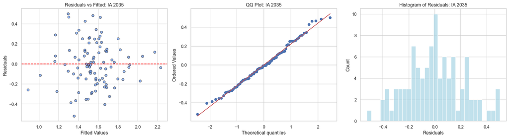

```
--- IA 2035 ---
Kolmogorov-Smirnov Test for Normality:
D = 0.0493 | p-value = 0.9617
Breusch-Pagan Test for Homoskedasticity:
Chi-Sq = 20.8808 | p-value = 0.0219
```

```python
lm_IA2035btm_int = lm_generation_interactions(df2035btm, state)
print(lm_IA2035btm_int.summary())
diagnostic_plots(lm_IA2035btm_int, f"{state} 2035")
```

#### California

##### 2025

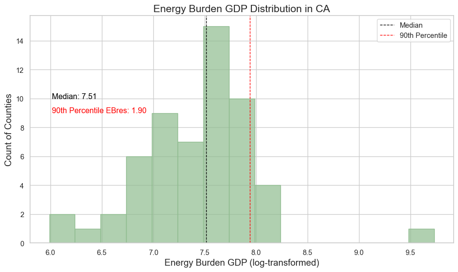

```
Median EBres: [1.20279706]
```

```python
state = "CA"

hist_plot = plot_energy_gdp_histogram(state, df2025btm)
if hist_plot:
    hist_plot.show()

print("Median EBres:", summary_EBres_2025.loc[summary_EBres_2025['state'] == state, 'median_ebres'].values)
```

```
CA BTM 2025
Pearson Correlation (Box-Cox): 0.232
Kendall Correlation (Raw): 0.213
```

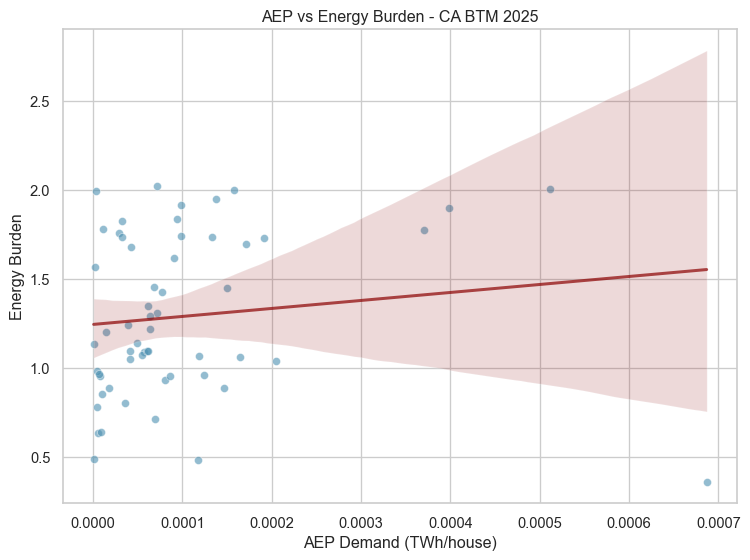

```
  state   pearson   kendall
0    CA  0.232057  0.213033
```

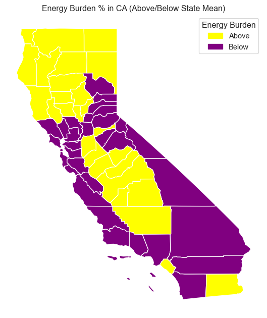

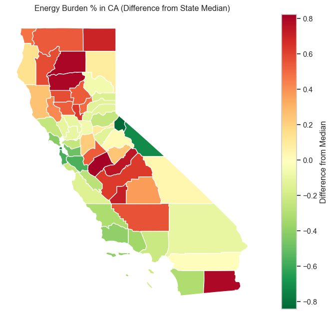

```python
corrCA_2025 = corrAEP_EB_State(df2025btm, 'BTM', '2025', state)
print(corrCA_2025)
EB_county_map_state(df2025btm, summary_EBres_2025, state_abbr=state)
```

Model without interactions

```
                            OLS Regression Results
==============================================================================
Dep. Variable:                  EBres   R-squared:                       0.580
Model:                            OLS   Adj. R-squared:                  0.547
Method:                 Least Squares   F-statistic:                     17.93
Date:                Thu, 16 Oct 2025   Prob (F-statistic):           2.62e-09
Time:                        10:38:46   Log-Likelihood:                -10.386
No. Observations:                  57   AIC:                             30.77
Df Residuals:                      52   BIC:                             40.99
Df Model:                           4
Covariance Type:            nonrobust
==============================================================================================
                                 coef    std err          t      P>|t|      [0.025      0.975]
----------------------------------------------------------------------------------------------
Intercept                      1.0832      0.131      8.285      0.000       0.821       1.345
UnemploymentRate               0.0393      0.026      1.519      0.135      -0.013       0.091
Q("Poverty%_standardized")     0.2950      0.075      3.947      0.000       0.145       0.445
AgricultureInd                 0.0127      0.007      1.844      0.071      -0.001       0.027
NonWhite_standardized         -0.0380      0.043     -0.880      0.383      -0.125       0.049
==============================================================================
Omnibus:                       11.226   Durbin-Watson:                   1.860
Prob(Omnibus):                  0.004   Jarque-Bera (JB):               17.419
Skew:                          -0.613   Prob(JB):                     0.000165
Kurtosis:                       5.415   Cond. No.                         40.4
==============================================================================

Notes:
[1] Standard Errors assume that the covariance matrix of the errors is correctly specified.
```

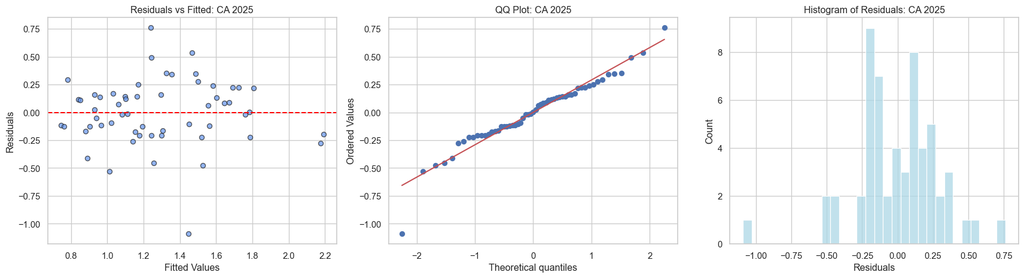

```
--- CA 2025 ---
Kolmogorov-Smirnov Test for Normality:
D = 0.0987 | p-value = 0.5997
Breusch-Pagan Test for Homoskedasticity:
Chi-Sq = 3.5672 | p-value = 0.4677
```

```python
lm_CA2025btm = lm_generation(df2025btm, state)
print(lm_CA2025btm.summary())
diagnostic_plots(lm_CA2025btm, f"{state} 2025")
```

Model with interactions

```
                            OLS Regression Results
==============================================================================
Dep. Variable:                  EBres   R-squared:                       0.638
Model:                            OLS   Adj. R-squared:                  0.559
Method:                 Least Squares   F-statistic:                     8.108
Date:                Thu, 16 Oct 2025   Prob (F-statistic):           2.27e-07
Time:                        10:38:46   Log-Likelihood:                -6.1279
No. Observations:                  57   AIC:                             34.26
Df Residuals:                      46   BIC:                             56.73
Df Model:                          10
Covariance Type:            nonrobust
====================================================================================================================
                                                       coef    std err          t      P>|t|      [0.025      0.975]
--------------------------------------------------------------------------------------------------------------------
Intercept                                            1.4363      0.347      4.144      0.000       0.739       2.134
UnemploymentRate                                    -0.0414      0.066     -0.631      0.531      -0.173       0.091
Q("Poverty%_standardized")                           0.4036      0.290      1.390      0.171      -0.181       0.988
AgricultureInd                                       0.0806      0.031      2.597      0.013       0.018       0.143
NonWhite_standardized                               -0.5664      0.278     -2.038      0.047      -1.126      -0.007
UnemploymentRate:Q("Poverty%_standardized")         -0.0337      0.061     -0.555      0.582      -0.156       0.088
UnemploymentRate:AgricultureInd                     -0.0090      0.005     -1.878      0.067      -0.019       0.001
UnemploymentRate:NonWhite_standardized               0.1112      0.052      2.121      0.039       0.006       0.217
Q("Poverty%_standardized"):AgricultureInd           -0.0023      0.017     -0.135      0.893      -0.037       0.032
Q("Poverty%_standardized"):NonWhite_standardized    -0.0030      0.094     -0.032      0.975      -0.192       0.186
AgricultureInd:NonWhite_standardized                -0.0093      0.009     -1.014      0.316      -0.028       0.009
==============================================================================
Omnibus:                       10.107   Durbin-Watson:                   2.158
Prob(Omnibus):                  0.006   Jarque-Bera (JB):               13.177
Skew:                          -0.629   Prob(JB):                      0.00138
Kurtosis:                       4.991   Cond. No.                     1.17e+03
==============================================================================

Notes:
[1] Standard Errors assume that the covariance matrix of the errors is correctly specified.
[2] The condition number is large, 1.17e+03. This might indicate that there are
strong multicollinearity or other numerical problems.
```

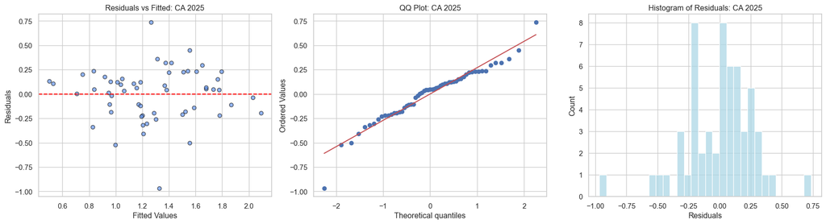

```
--- CA 2025 ---
Kolmogorov-Smirnov Test for Normality:
D = 0.1090 | p-value = 0.4738
Breusch-Pagan Test for Homoskedasticity:
Chi-Sq = 9.5607 | p-value = 0.4798
```

```python
lm_CA2025btm_int = lm_generation_interactions(df2025btm, state)
print(lm_CA2025btm_int.summary())
diagnostic_plots(lm_CA2025btm_int, f"{state} 2025")
```

##### 2035

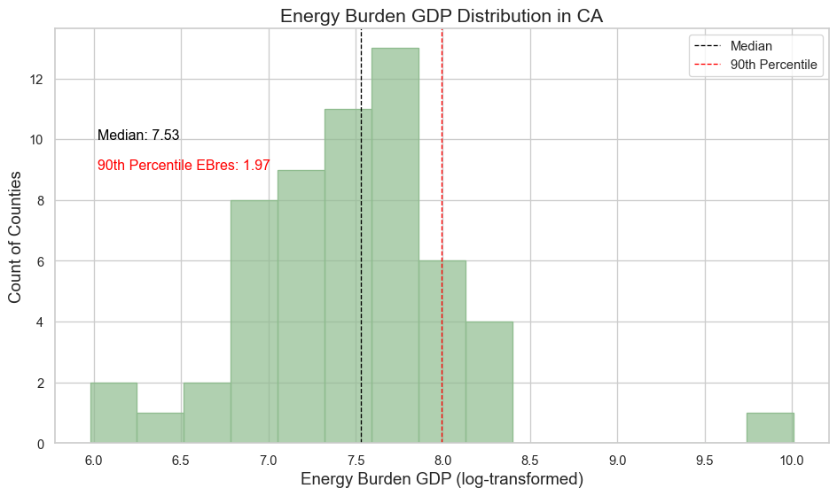

```
Median EBres: [1.25885223]
```

```python
state = "CA"

hist_plot = plot_energy_gdp_histogram(state, df2035btm)
if hist_plot:
    hist_plot.show()

print("Median EBres:", summary_EBres_2035.loc[summary_EBres_2035['state'] == state, 'median_ebres'].values)
```

```
CA BTM 2035
Pearson Correlation (Box-Cox): 0.229
Kendall Correlation (Raw): 0.212
```

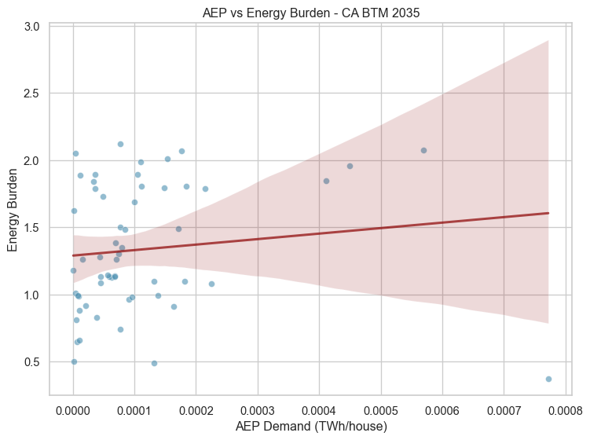

```
  state   pearson   kendall
0    CA  0.228831  0.211779
```

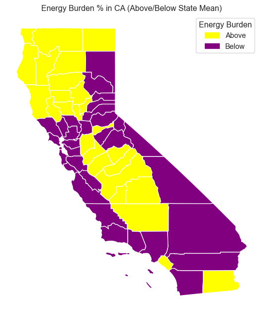

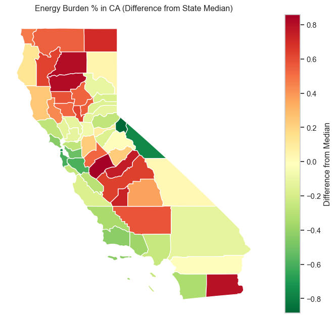

```python
corrCA_2035 = corrAEP_EB_State(df2035btm, 'BTM', '2035', state)
print(corrCA_2035)
EB_county_map_state(df2035btm, summary_EBres_2035, state_abbr=state)
```

Model without interactions

```
                            OLS Regression Results
==============================================================================
Dep. Variable:                  EBres   R-squared:                       0.576
Model:                            OLS   Adj. R-squared:                  0.543
Method:                 Least Squares   F-statistic:                     17.65
Date:                Thu, 16 Oct 2025   Prob (F-statistic):           3.29e-09
Time:                        10:38:48   Log-Likelihood:                -12.926
No. Observations:                  57   AIC:                             35.85
Df Residuals:                      52   BIC:                             46.07
Df Model:                           4
Covariance Type:            nonrobust
==============================================================================================
                                 coef    std err          t      P>|t|      [0.025      0.975]
----------------------------------------------------------------------------------------------
Intercept                      1.1275      0.137      8.249      0.000       0.853       1.402
UnemploymentRate               0.0396      0.027      1.465      0.149      -0.015       0.094
Q("Poverty%_standardized")     0.3121      0.078      3.985      0.000       0.155       0.469
AgricultureInd                 0.0130      0.007      1.800      0.078      -0.001       0.028
NonWhite_standardized         -0.0365      0.045     -0.808      0.423      -0.127       0.054
==============================================================================
Omnibus:                       10.392   Durbin-Watson:                   1.866
Prob(Omnibus):                  0.006   Jarque-Bera (JB):               15.004
Skew:                          -0.592   Prob(JB):                     0.000552
Kurtosis:                       5.217   Cond. No.                         40.4
==============================================================================

Notes:
[1] Standard Errors assume that the covariance matrix of the errors is correctly specified.
```

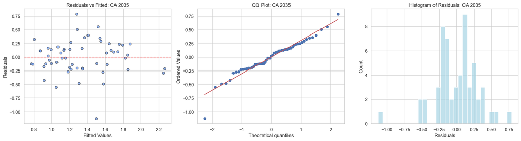

```
--- CA 2035 ---
Kolmogorov-Smirnov Test for Normality:
D = 0.0869 | p-value = 0.7496
Breusch-Pagan Test for Homoskedasticity:
Chi-Sq = 3.7061 | p-value = 0.4472
```

```python
lm_CA2035btm = lm_generation(df2035btm, state)
print(lm_CA2035btm.summary())
diagnostic_plots(lm_CA2035btm, f"{state} 2035")
```

Model with interactions

```
                            OLS Regression Results
==============================================================================
Dep. Variable:                  EBres   R-squared:                       0.636
Model:                            OLS   Adj. R-squared:                  0.556
Method:                 Least Squares   F-statistic:                     8.025
Date:                Thu, 16 Oct 2025   Prob (F-statistic):           2.60e-07
Time:                        10:38:48   Log-Likelihood:                -8.5976
No. Observations:                  57   AIC:                             39.20
Df Residuals:                      46   BIC:                             61.67
Df Model:                          10
Covariance Type:            nonrobust
====================================================================================================================
                                                       coef    std err          t      P>|t|      [0.025      0.975]
--------------------------------------------------------------------------------------------------------------------
Intercept                                            1.4983      0.363      4.126      0.000       0.767       2.229
UnemploymentRate                                    -0.0454      0.069     -0.661      0.512      -0.184       0.093
Q("Poverty%_standardized")                           0.4138      0.304      1.362      0.180      -0.198       1.026
AgricultureInd                                       0.0858      0.032      2.647      0.011       0.021       0.151
NonWhite_standardized                               -0.6037      0.291     -2.077      0.043      -1.189      -0.019
UnemploymentRate:Q("Poverty%_standardized")         -0.0326      0.063     -0.514      0.610      -0.160       0.095
UnemploymentRate:AgricultureInd                     -0.0097      0.005     -1.940      0.059      -0.020       0.000
UnemploymentRate:NonWhite_standardized               0.1189      0.055      2.168      0.035       0.009       0.229
Q("Poverty%_standardized"):AgricultureInd           -0.0024      0.018     -0.132      0.895      -0.038       0.034
Q("Poverty%_standardized"):NonWhite_standardized    -0.0081      0.098     -0.082      0.935      -0.206       0.190
AgricultureInd:NonWhite_standardized                -0.0098      0.010     -1.024      0.311      -0.029       0.009
==============================================================================
Omnibus:                        9.468   Durbin-Watson:                   2.159
Prob(Omnibus):                  0.009   Jarque-Bera (JB):               11.759
Skew:                          -0.609   Prob(JB):                      0.00280
Kurtosis:                       4.862   Cond. No.                     1.17e+03
==============================================================================

Notes:
[1] Standard Errors assume that the covariance matrix of the errors is correctly specified.
[2] The condition number is large, 1.17e+03. This might indicate that there are
strong multicollinearity or other numerical problems.
```

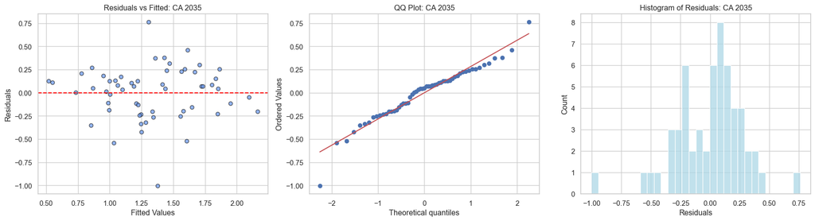

```
--- CA 2035 ---
Kolmogorov-Smirnov Test for Normality:
D = 0.1118 | p-value = 0.4420
Breusch-Pagan Test for Homoskedasticity:
Chi-Sq = 9.6062 | p-value = 0.4757
```

```python
lm_CA2035btm_int = lm_generation_interactions(df2035btm, state)
print(lm_CA2035btm_int.summary())
diagnostic_plots(lm_CA2035btm_int, f"{state} 2035")
```